# STAT 479: Causal Inference – Midterm Study Guide

Weeks 1-7 | Exam: March 12, 2026

**Format:** Free response / short answer on blank paper. One sheet (front+back) cheat sheet allowed. Calculator (any) allowed. **65 minutes + 5 minutes reading time. 7 problems, 75 points total. Maximum possible score = 65 (10-point buffer).** Try to answer as many questions as you can.

## How to Use This Guide

Read it start to finish like a story. Every concept is explained in plain English first, then the math version follows. When you see a new term, it will always be defined right there in normal words before any formula appears. The math is there so you can reproduce it on the exam, but the goal is for you to actually **understand** what is going on first.

The R code chunks generate graphs that visualize each concept. Knit with `Ctrl+Shift+K` in RStudio.

# 1. The Big Picture

## What is this class actually about?

This class is about one question: **“Did this thing actually cause that outcome, or is it just a coincidence?”**

That sounds simple, but it turns out to be really hard. Here is a classic example:

> People who go to college earn more money than people who don’t. Does college **cause** higher earnings? Or is it that the kinds of people who go to college (wealthier families, better schools, more motivated) would have earned more anyway?

That is the core problem this class tries to solve. The naive answer (“just compare the two groups”) is almost always wrong because the two groups are different in ways that have nothing to do with the treatment.

## The one sentence summary of the whole course

**To figure out if something causes something else, you need to compare apples to apples – and this class teaches you all the ways to do that (or at least try to).**

# 2. Key Vocabulary

Before we go any further, let me define every important term in plain English. Refer back to this section whenever you see a word you don’t recognize.

### Treatment ($Z$)

The thing whose effect you want to measure. It is binary (yes/no, 1/0) in this class.

- Examples: taking a drug vs. placebo, getting a college degree vs. not, seeing an ad vs. not seeing it
- $Z = 1$ means “treated” (got the thing), $Z = 0$ means “control” (didn’t get it)

### Outcome ($Y$)

The result you are measuring. The thing you think might be affected by the treatment.

- Examples: income, test score, whether someone bought a product, health outcome

### Covariates ($X$)

**Background characteristics** of a person/unit that exist **before** the treatment happens. Think of these as “things about a person that might matter.”

- Examples: age, gender, family income, education level, prior health conditions, browsing history
- These are also called “pre-treatment variables” – they describe who someone is before any treatment is applied
- A covariate is literally just a variable that could vary together with (co-vary with) the treatment and the outcome

### Confounders

A confounder is a covariate that affects **both** the treatment and the outcome. This is the source of all problems in causal inference.

**Example:** Family wealth is a confounder for the college-earnings question. Wealthy families are more likely to send kids to college (affects treatment), AND kids from wealthy families earn more regardless of college (affects outcome). So if you just compare college grads to non-grads, part of the earnings difference is from college, and part is from family wealth.

### Treatment Effect

How much the treatment changes the outcome. If taking a drug lowers your blood pressure by 10 points, the treatment effect is -10.

### Average Treatment Effect (ATE)

The average treatment effect across a whole group of people. Some people might benefit a lot, some a little, some not at all – the ATE is the average across everyone: $\tau = \frac{1}{N}\sum[Y_i(1) - Y_i(0)]$.

### ATT (Average Treatment Effect on the Treated)

The average effect among people who actually received treatment: $\text{ATT} = \mathbb{E}[Y_i(1) - Y_i(0) \mid Z_i = 1]$. This answers: “did the treatment help the people who got it?”

### ATC (Average Treatment Effect on the Control)

The average effect among people who did NOT receive treatment: $\text{ATC} = \mathbb{E}[Y_i(1) - Y_i(0) \mid Z_i = 0]$. This answers: “would the untreated have benefited if they had been treated?”

In a randomized experiment, ATE = ATT = ATC (because treated and control groups are representative of the whole population). In observational studies, they can differ.

### Selection Bias

The problem that arises when the people who get treated are **systematically different** from the people who don’t, even before treatment. If healthier people are more likely to exercise, then comparing exercisers to non-exercisers overestimates the effect of exercise (because exercisers were healthier to begin with).

### Potential Outcomes

The imaginary “what if” outcomes. For each person, there are two potential outcomes:

- $Y_i(1)$: what **would** happen to person $i$ if they got the treatment
- $Y_i(0)$: what **would** happen to person $i$ if they did NOT get the treatment

The problem: you only ever see ONE of these. If someone went to college, you see their income with college, but you’ll never know what their income would have been without it. The one you don’t see is called the **counterfactual**.

### Estimand

The thing you are trying to estimate. Your target. In this class, the main estimand is the average treatment effect.

### Estimator

The formula or method you use to try to estimate the estimand. For example, “take the average outcome of the treated group minus the average outcome of the control group” is an estimator.

### Unbiased

An estimator is unbiased if, on average (across many hypothetical repetitions of the study), it gives you the right answer. It might be a little high or a little low in any one study, but it’s not systematically off in one direction.

### Variance (of an estimator)

How much the estimator bounces around from study to study. Low variance = precise, high variance = noisy. Even an unbiased estimator can be useless if the variance is huge.

### Consistency (assumption)

The observed outcome equals the potential outcome corresponding to the treatment actually received. In symbols: if $Z_i = 1$, then $Y_i^{\text{obs}} = Y_i(1)$. If $Z_i = 0$, then $Y_i^{\text{obs}} = Y_i(0)$. This seems obvious but it is doing real work – it says there are no hidden versions of treatment that would change what $Y_i(1)$ means. (This is closely related to SUTVA.)

### Propensity Score

The probability that a person gets treated, based on their background characteristics. If you are young, healthy, and wealthy, maybe you have a 70% chance of getting the treatment. That 70% is your propensity score. Formally: $e(X) = \Pr(Z = 1 \mid X)$.

### Tower Property (Law of Iterated Expectations)

A math rule that says: you can compute an overall average by first averaging within subgroups, then averaging across subgroups. In symbols: $\mathbb{E}[Y] = \mathbb{E}[\mathbb{E}[Y \mid X]]$. This comes up repeatedly in the identification proofs and in showing IPW is unbiased. Think of it as: “the average of the group averages is the overall average” (when you weight by group size).

# 3. Week 1: Regression – A Flawed But Useful First Tool

## 3.1 The Problem Regression Tries to Solve

You want to know: does treatment $Z$ affect outcome $Y$? But there are confounders $X$ (background characteristics) muddying the waters.

**Example:** Does a college degree ($Z$) increase income ($Y$)? Family background ($X$) is a confounder – it makes people more likely to go to college AND makes them earn more.

If you just compare average income of college grads vs. non-grads, you get a mix of the college effect and the family background effect. You can’t tell them apart.

**Regression tries to “hold constant” the confounders** so you can isolate the treatment effect.

## 3.2 What the Regression Model Says

The model is:

$$Y = \tau Z + \beta^\top X +
\varepsilon$$

(The notation $\beta^\top X$ just means “a weighted combination of all your background characteristics.” If $X$ has three variables – age, income, education – then $\beta^\top X = \beta_1 \cdot \text{age} + \beta_2 \cdot \text{income} + \beta_3 \cdot \text{education}$. The $\beta$’s are the weights that regression figures out.)

In plain English:

> Your outcome ($Y$) equals the treatment effect ($\tau$) times whether you got treated ($Z$), plus the effect of your background ($\beta^\top X$), plus random noise ($\varepsilon$).

The coefficient $\tau$ is the thing you care about. It represents: **if two people had the exact same background ($X$), but one got treated and the other didn’t, how much would their outcomes differ?**

**The catch:** This only works if the model is correct. If the real relationship between $X$ and $Y$ is not a straight line (it’s curved, or there are interactions, etc.), then $\tau$ can be wrong.

## 3.3 The Frisch-Waugh-Lovell (FWL) Theorem

This theorem explains **what regression is actually doing under the hood**. It is the most important result from Week 1.

### Plain English version

When you run a regression of $Y$ on both $Z$ and $X$, the coefficient on $Z$ is the same thing you’d get if you:

1. First predicted $Z$ from $X$ (how well can you guess treatment status from background?)
2. Took the **leftover** part of $Z$ that $X$ can’t predict (call this $\tilde{Z}$)
3. Looked at how that leftover relates to $Y$

Think of it like this: regression strips away everything about treatment assignment that can be explained by background characteristics, and then sees if the **unexplained** part of treatment is related to the outcome.

### The math

The residual from regressing $Z$ on $X$ is:

$$\tilde{Z}_i = Z_i - \hat{\mathbb{E}}[Z
\mid X_i]$$

This is the “part of treatment that can’t be explained by covariates.”

The regression coefficient on $Z$ is then:

$$\hat{\tau} = \frac{\sum_{i=1}^{n}
\tilde{Z}_i Y_i}{\sum_{i=1}^{n} \tilde{Z}_i^2}$$

### Visualizing FWL: The Residualization

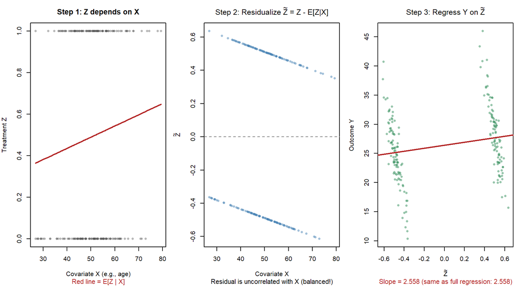

```r
# ----- Generate observational data with a confounder -----
n <- 200
X <- rnorm(n, 50, 10)                    # covariate (e.g., age)
Z <- rbinom(n, 1, plogis(-2 + 0.04 * X)) # treatment depends on X
Y <- 3 * Z + 0.5 * X + rnorm(n, 0, 3)   # outcome depends on both

# ----- FWL step 1: regress Z on X, get residuals -----
Z_on_X <- lm(Z ~ X)
Z_tilde <- resid(Z_on_X)  # the part of Z that X can't explain

# ----- FWL step 2: regress Y on Z_tilde -----
fwl_fit <- lm(Y ~ Z_tilde)
tau_fwl <- coef(fwl_fit)["Z_tilde"]

# compare to full regression
full_fit <- lm(Y ~ Z + X)
tau_full <- coef(full_fit)["Z"]

# ----- Plot -----
par(mfrow = c(1, 3), mar = c(5.5, 4, 3, 1))

# Panel 1: Z vs X -- treatment depends on the covariate
plot(X, Z, pch = 16, col = adjustcolor("gray30", 0.4), cex = 0.8,
     main = "Step 1: Z depends on X",
     xlab = "Covariate X (e.g., age)", ylab = "Treatment Z")
lines(sort(X), fitted(Z_on_X)[order(X)], col = "firebrick", lwd = 2)
mtext("Red line = E[Z | X]", side = 1, line = 4, cex = 0.7, col = "firebrick")

# Panel 2: Z_tilde -- the residual (part X can't explain)
plot(X, Z_tilde, pch = 16, col = adjustcolor("steelblue", 0.5), cex = 0.8,
     main = expression("Step 2: Residualize " * tilde(Z) * " = Z - E[Z|X]"),
     xlab = "Covariate X", ylab = expression(tilde(Z)))
abline(h = 0, lty = 2, col = "gray50")
mtext("Residual is uncorrelated with X (balanced!)", side = 1, line = 4, cex = 0.7)

# Panel 3: Y vs Z_tilde -- the FWL regression
plot(Z_tilde, Y, pch = 16, col = adjustcolor("seagreen", 0.5), cex = 0.8,
     main = expression("Step 3: Regress Y on " * tilde(Z)),
     xlab = expression(tilde(Z)), ylab = "Outcome Y")
abline(fwl_fit, col = "firebrick", lwd = 2)
mtext(paste0("Slope = ", round(tau_fwl, 3), " (same as full regression: ",
             round(tau_full, 3), ")"),
      side = 1, line = 4, cex = 0.7, col = "firebrick")
```

**What you see:** Panel 2 is the key – after residualizing, the “treatment residual” is uncorrelated with X. Regression has stripped out the confounder. The slope in Panel 3 IS the regression coefficient on Z from the full model.

## 3.4 Regression as a Reweighting/Balancing Trick

Here is the deeper insight. Regression is not just fitting a line. It is actually **reweighting** people so that the treated and control groups look the same on their background characteristics.

Define the regression weights:

$$w_i = \frac{\tilde{Z}_i}{\sum_{j=1}^{n}
\tilde{Z}_j^2}$$

Then the key result is:

$$\sum_{i=1}^{n} w_i X_i = 0$$

**What this means in plain English:** After reweighting, the weighted average of the background characteristics is exactly the same between the treated and control groups. Regression has “balanced” the groups.

And you can write the estimator as:

$$\hat{\tau} = \sum_{i: Z_i=1} w_i Y_i -
\sum_{i: Z_i=0} (-w_i) Y_i$$

This is just a weighted comparison of outcomes between the two groups, where the weights force the groups to look the same on $X$.

**Additional property:** The weights sum to 1 within each group. That is, $\sum_{i: Z_i=1} w_i = 1$ and $\sum_{i: Z_i=0} (-w_i) = 1$. Quick proof: set $Y_i = Z_i$ in the regression. Then $\hat{\tau}$ must equal 1 (since the regression coefficient on $Z$ when $Y = Z$ is trivially 1). But $\hat{\tau} = \sum w_i Y_i = \sum_{i: Z_i=1} w_i \cdot 1 + \sum_{i: Z_i=0} w_i \cdot 0 = \sum_{i: Z_i=1} w_i = 1$.

## 3.5 When Regression Fails

Here is the critical limitation.

Suppose the **real** relationship between $X$ and $Y$ is nonlinear (say $Y$ depends on $X^2$, or $\log(X)$, or some other curvy function), but you just put $X$ in your regression as a straight line.

Regression balances $X$ perfectly ($\sum w_i X_i = 0$), but it does **not** balance $X^2$ or $\log(X)$ or any other nonlinear function you didn’t include.

**The bias from misspecification is:**

$$\text{Bias} = \frac{\sum_{i=1}^{n}
\tilde{Z}_i \, g(X_i)}{\sum_{i=1}^{n} \tilde{Z}_i^2}$$

where $g(X)$ is the nonlinear part you left out.

### Visualizing Misspecification Bias

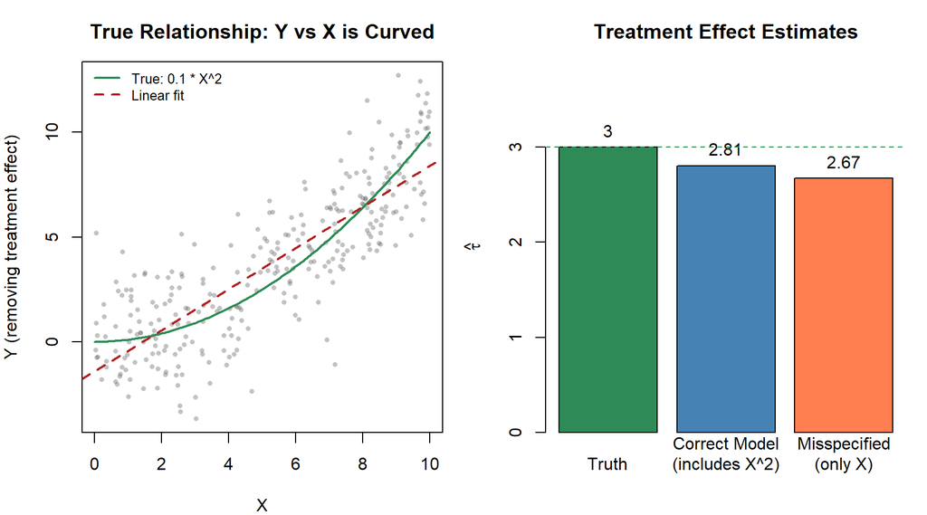

```r
# ----- Data where the TRUE relationship is quadratic -----
n <- 300
X <- runif(n, 0, 10)
Z <- rbinom(n, 1, plogis(-1 + 0.2 * X))  # treatment depends on X
# TRUE model: Y depends on X^2 (nonlinear!), but we only put X in the regression
Y <- 3 * Z + 0.1 * X^2 + rnorm(n, 0, 2)

# --- Correct model (includes X^2) ---
correct_fit <- lm(Y ~ Z + X + I(X^2))
tau_correct <- coef(correct_fit)["Z"]

# --- Misspecified model (only includes X, not X^2) ---
wrong_fit <- lm(Y ~ Z + X)
tau_wrong <- coef(wrong_fit)["Z"]

# ----- Plot -----
par(mfrow = c(1, 2), mar = c(4, 4, 3, 1))

# Panel 1: the true relationship is curved
plot(X, Y - 3 * Z, pch = 16, col = adjustcolor("gray40", 0.4), cex = 0.6,
     main = "True Relationship: Y vs X is Curved",
     xlab = "X", ylab = "Y (removing treatment effect)")
curve(0.1 * x^2, from = 0, to = 10, add = TRUE, col = "seagreen", lwd = 2)
abline(lm((Y - 3 * Z) ~ X), col = "firebrick", lwd = 2, lty = 2)
legend("topleft", legend = c("True: 0.1 * X^2", "Linear fit"),
       col = c("seagreen", "firebrick"), lwd = 2, lty = c(1, 2), bty = "n", cex = 0.8)

# Panel 2: how estimates compare
ests_compare <- c(3, tau_correct, tau_wrong)
names(ests_compare) <- c("Truth", "Correct Model\n(includes X^2)", "Misspecified\n(only X)")
bp <- barplot(ests_compare, col = c("seagreen", "steelblue", "coral"),
        main = "Treatment Effect Estimates",
        ylab = expression(hat(tau)), ylim = c(0, max(ests_compare) * 1.3))
text(bp, ests_compare, labels = round(ests_compare, 2), pos = 3)
abline(h = 3, lty = 2, col = "seagreen")
```

**Concrete numerical example (from practice problems):** Treated: $(X, Y) = (1, 1), (3, 9)$. Control: $(X, Y) = (2, 4), (2, 4)$. The means are $\bar{X}_T = 2 = \bar{X}_C$ – perfectly balanced! But $\bar{X^2}_T = 5 \neq 4 = \bar{X^2}_C$. The true outcome model is $Y = X^2$, so the treatment effect is zero. Yet linear regression reports a nonzero $\hat{\tau}$ because it balances $X$ but not $X^2$.

**Another example of misspecification:** Suppose income ($Y$) depends on education ($X$) in a curvy way: people with very high education earn *much* more (the curve bends upward). You run a linear regression of $Y$ on treatment $Z$ and education $X$. The regression perfectly balances education: the weighted average education is the same in both groups. But it does NOT balance $X^2$ (education squared). If treated people happen to have more extreme education values (some very high, some very low), then $\sum w_i X_i^2 \neq 0$, and the curvy relationship between education and income bleeds into your treatment effect estimate.

## 3.6 The Extrapolation Problem

This is a separate failure mode that the practice problems emphasize.

**What it is:** If the treated people and control people have very different values of $X$ (say treated people are all ages 60-80 and controls are all ages 20-40), then there is a gap in the middle where you have NO data from either group. Regression draws a straight line through that gap and pretends it knows what would happen there. That is **extrapolation** – making up answers where you have no evidence.

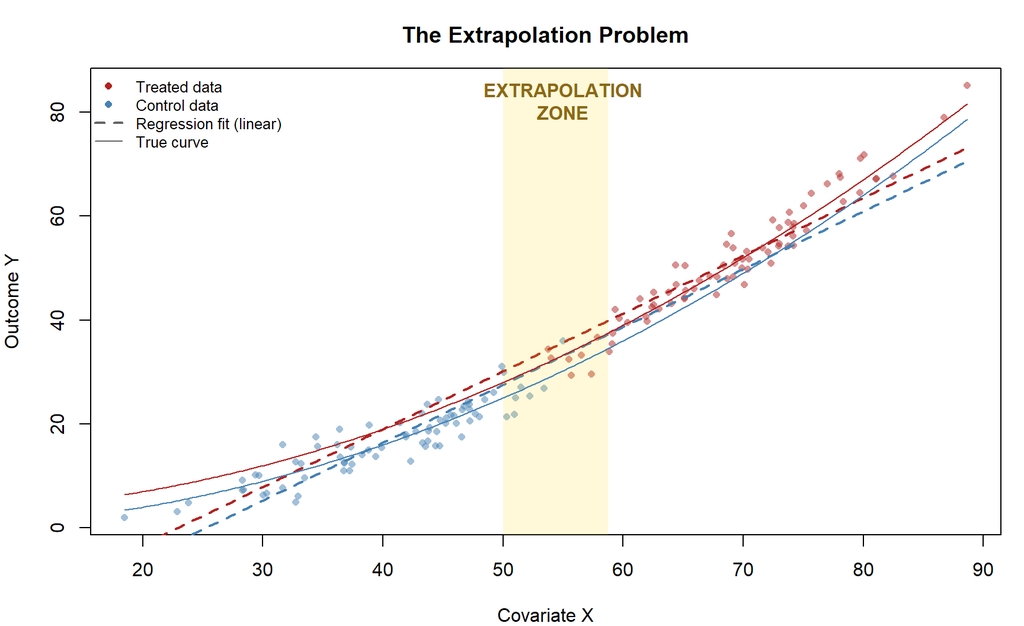

```r
# ----- Generate data with poor overlap -----
n <- 150
X_t <- rnorm(75, mean = 70, sd = 8)
X_c <- rnorm(75, mean = 40, sd = 8)
X <- c(X_t, X_c)
Z <- c(rep(1, 75), rep(0, 75))

# true outcome: NONLINEAR in X
Y <- 3 * Z + 0.01 * X^2 + rnorm(n, 0, 3)

# fit linear regression (will extrapolate across the gap)
fit <- lm(Y ~ Z + X)

# ----- Plot -----
par(mar = c(4, 4, 3, 1))
plot(X, Y, pch = 16, col = adjustcolor(ifelse(Z == 1, "firebrick", "steelblue"), 0.5),
     cex = 0.8, main = "The Extrapolation Problem",
     xlab = "Covariate X", ylab = "Outcome Y")

# regression lines for each group
x_seq <- seq(min(X), max(X), length = 200)
lines(x_seq, predict(fit, newdata = data.frame(Z = 1, X = x_seq)),
      col = "firebrick", lwd = 2, lty = 2)
lines(x_seq, predict(fit, newdata = data.frame(Z = 0, X = x_seq)),
      col = "steelblue", lwd = 2, lty = 2)

# highlight the gap region
rect(max(X_c) - 5, par("usr")[3], min(X_t) + 5, par("usr")[4],
     col = adjustcolor("gold", 0.15), border = NA)
text(55, max(Y) - 3, "EXTRAPOLATION\nZONE", col = "goldenrod4", cex = 1, font = 2)

# true curves
lines(x_seq, 3 + 0.01 * x_seq^2, col = "firebrick", lwd = 1, lty = 1)
lines(x_seq, 0.01 * x_seq^2, col = "steelblue", lwd = 1, lty = 1)

legend("topleft",
       legend = c("Treated data", "Control data", "Regression fit (linear)", "True curve"),
       pch = c(16, 16, NA, NA), col = c("firebrick", "steelblue", "gray40", "gray40"),
       lty = c(NA, NA, 2, 1), lwd = c(NA, NA, 2, 1), bty = "n", cex = 0.8)
```

**How to detect it:** Make a histogram of $X$ for the treated group and a histogram of $X$ for the control group. If they barely overlap (the two groups live in different ranges of $X$), you are in trouble – regression is just guessing in the gap. Love plots and side-by-side histograms are your friends here.

## 3.7 When Regression IS Unbiased Despite Misspecification

There is one important special case where regression works even if the model is wrong.

**If who gets treated has nothing to do with their background** – meaning knowing someone’s age, income, etc. tells you nothing about whether they got treated ($\mathbb{E}[Z \mid X] = \mathbb{E}[Z]$, i.e., treatment doesn’t depend on $X$) – then the regression coefficient $\hat{\tau}$ gives you the right answer even if the model is totally wrong.

**Why?** Think about the FWL residual $\tilde{Z}_i$. If treatment has nothing to do with $X$, then trying to predict $Z$ from $X$ gives you basically the same prediction for everyone ($\bar{Z}$). So $\tilde{Z}_i \approx Z_i - \bar{Z}$, which is just “were you treated, minus the overall fraction treated.” This leftover has nothing to do with $X$, or $X^2$, or any function of $X$. So the bias term $\sum w_i g(X_i) \approx 0$ – the nonlinear stuff you left out of the model washes out.

**When does this happen?** In a **randomized experiment**. A coin flip (or random draw) doesn’t care about your age or income, so treatment is independent of $X$. This is why running a regression inside an experiment works even if the linear model is wrong – randomization kills the bias.

**When does it NOT work?** In an **observational study** where treatment depends on background characteristics. If sicker people are more likely to get the drug, then $\tilde{Z}_i$ is connected to health, and any nonlinear relationship between health and the outcome ($g(X)$) bleeds into your estimate.

## 3.8 Key Limitations Summary

Regression assumes:

- **Linearity:** the relationship between background and outcome is a straight line
- **Constant effects:** the treatment has the same effect on everyone
- **No extrapolation:** there is enough overlap between treated and control groups
- **No omitted variables:** all confounders are in the model

If any of these fail, your treatment effect estimate can be wrong.

# 4. Week 2: Randomized Experiments – The Gold Standard

## 4.1 Why Randomization Fixes Everything

In Week 1, we saw that regression can only balance what you put in the model. If you miss something, you are in trouble.

Randomization takes a completely different approach: **instead of trying to statistically adjust for confounders, you make them irrelevant by randomly deciding who gets treated.**

Think of it like shuffling a deck of cards and dealing to two piles. The piles will be roughly the same – not because you carefully sorted them, but because the random process doesn’t favor any particular card.

When you randomly assign treatment:

- The treated and control groups will be similar in age, gender, income, health, motivation, genetics, and **literally everything else** – including things you didn’t even think to measure
- Any differences between the groups are just due to luck, and they get smaller as the sample gets bigger
- You can make strong causal claims because the ONLY difference between the groups is the treatment

## 4.2 The Completely Randomized Design

**Setup:** You have $N$ people. You randomly pick $n_1$ of them to get the treatment. The remaining $n_0 = N - n_1$ are the control group.

Every possible way of choosing $n_1$ people out of $N$ is equally likely. There are $\binom{N}{n_1}$ possible assignments (read “N choose n_1” – this is the number of ways to pick $n_1$ items from $N$ total; for example, $\binom{10}{3} = 120$ means there are 120 ways to pick 3 people out of 10), and each has the same probability:

$$\Pr(\mathbf{Z} = \mathbf{z}) =
\binom{N}{n_1}^{-1}$$

Each person has a $n_1/N$ chance of being treated.

**Important detail:** The assignments are NOT independent across people. If I tell you person 1 got treated, that slightly lowers the chance person 2 got treated (because there are now fewer treatment “slots” left). This is because the total number treated is fixed at $n_1$.

## 4.3 What Randomization Balances

This is the key section. Randomization balances **everything**.

### Balances averages of background characteristics

For any background characteristic $X$ (age, income, whatever):

$$\mathbb{E}[\bar{X}_T - \bar{X}_C] =
0$$

### Balances ANY function of background characteristics

For **any** function $g(X)$ – could be $X^2$, could be $\log(X)$, could be some crazy nonlinear thing:

$$\mathbb{E}[\bar{g}_T - \bar{g}_C] =
0$$

Remember, regression could only balance the linear functions you put in the model. Randomization balances **everything** – including functions you didn’t know about.

### Balances things you can’t even see

Let $U$ be some unmeasured characteristic (like genetic predisposition, or personality):

$$\mathbb{E}[\bar{U}_T - \bar{U}_C] =
0$$

This is the killer feature. Randomization handles confounders **you don’t even know about**. No other method can do this.

### Visualizing: Randomization Balances Everything (Including Unobserved Variables)

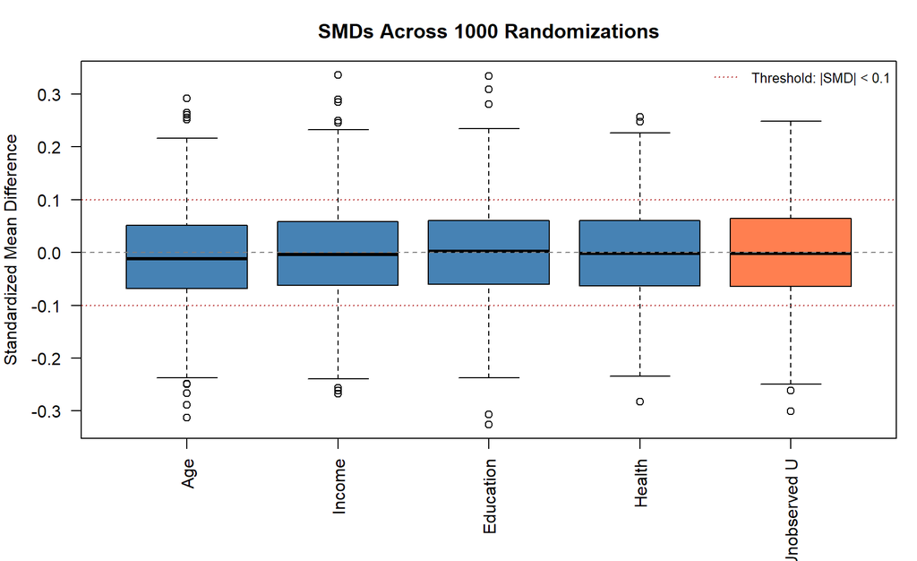

```r
# ----- Population of 500 people with many covariates -----
N <- 500
n1 <- 250
pop <- data.frame(
  age      = rnorm(N, 40, 12),
  income   = rnorm(N, 60000, 20000),
  educ     = rpois(N, 14),
  health   = rbeta(N, 5, 2) * 100,
  secret_U = rnorm(N, 0, 1)  # UNOBSERVED confounder -- you'd never know this exists
)

# ----- Compute SMDs across 1000 randomizations -----
n_sims <- 1000
smd_mat <- matrix(NA, n_sims, 5)
colnames(smd_mat) <- c("Age", "Income", "Education", "Health", "Unobserved U")

for (s in 1:n_sims) {
  Z <- rep(0, N); Z[sample(1:N, n1)] <- 1
  for (j in 1:5) {
    x <- pop[, j]
    x_t <- x[Z == 1]; x_c <- x[Z == 0]
    pooled_sd <- sqrt((var(x_t) + var(x_c)) / 2)
    smd_mat[s, j] <- (mean(x_t) - mean(x_c)) / pooled_sd
  }
}

# ----- Boxplot of SMDs -----
par(mar = c(6, 4, 3, 1))
boxplot(smd_mat, col = c(rep("steelblue", 4), "coral"),
        main = "SMDs Across 1000 Randomizations",
        ylab = "Standardized Mean Difference", las = 2)
abline(h = 0, lty = 2, col = "gray50")
abline(h = c(-0.1, 0.1), lty = 3, col = "firebrick")
legend("topright", legend = c("Threshold: |SMD| < 0.1"),
       lty = 3, col = "firebrick", bty = "n", cex = 0.8)
```

**What you see:** ALL covariates – including the unobserved one (coral) – are tightly centered around SMD = 0. Randomization balances things you cannot see. No other method can do this.

### Balance gets tighter with bigger samples

Hoeffding’s inequality says the probability of a big imbalance drops exponentially as $N$ grows:

$$\Pr\left(|\bar{X}_T - \bar{X}_C| >
\epsilon\right) \le 2\exp\left(-\frac{2n_1 n_0}{N} \cdot
\frac{\epsilon^2}{(b-a)^2}\right)$$

where $(b-a)$ is the range of the covariate and $\epsilon$ is how much imbalance you are worried about. You do not need to memorize this formula. The takeaway: in large experiments, big accidental imbalances are astronomically unlikely.

## 4.4 Regression vs. Randomization Comparison

|  | Regression | Randomization |
| --- | --- | --- |
| Balances the covariates you include | Yes | Yes |
| Balances nonlinear functions of covariates | **No** | Yes |
| Balances stuff you can’t observe | **No** | Yes |
| Requires a model to be correct | Yes | **No** |
| Requires assumptions about the outcome | Yes | **No** |

This is why randomized experiments are called the **gold standard** – they handle everything regression can’t.

## 4.5 Other Randomization Designs

The completely randomized design is the simplest, but there are several variants:

### Blocked (Stratified) Randomization

Divide the $N$ units into $K$ blocks based on covariates (e.g., block 1 = young, block 2 = old), then randomize separately within each block.

$$\Pr(\mathbf{Z} = \mathbf{z}) =
\prod_{k=1}^{K} \binom{n_k}{m_k}^{-1}$$

where $n_k$ is the block size and $m_k$ is the number treated in block $k$. When $K = 1$, this reduces to a completely randomized design.

**The blocked estimator:** $\hat{\tau}_{BL} = \sum_{k=1}^{K} \frac{n_k}{N}(\bar{Y}_{T,k} - \bar{Y}_{C,k})$

**Why block?** Blocking removes between-block variation from the estimator. If age strongly predicts the outcome, blocking on age ensures the treated and control groups have identical age distributions – not just balanced in expectation, but *exactly* balanced. This reduces variance compared to pure randomization.

### Bernoulli Trials

Each unit is assigned to treatment independently with probability $p$: $\Pr(Z_i = 1) = p$, independently across $i$.

**Key difference:** The number of treated units is *random* (Binomial$(N, p)$), not fixed. You could end up with all treated or all control by bad luck.

**Advantage:** Simple, easy to implement sequentially (don’t need to know $N$ in advance).

**Disadvantage:** Imbalanced group sizes possible.

### Paired Randomization

The strongest form of blocking. Pair up units (e.g., two similar patients), then randomly assign one to treatment and one to control within each pair.

**Advantage:** Very strong local balance – each matched pair is identical on observed covariates.

**Disadvantage:** Requires good pairing; analysis must respect the paired structure.

**Test statistic for paired designs:** $T = \sum_{b=1}^{B}(Y_{bT} - Y_{bC})$ – sum the within-pair differences.

### Cluster Randomization

Entire clusters (e.g., schools, hospitals) are assigned to treatment or control. All individuals within a treated cluster get treatment.

**Key issue:** The effective sample size is the number of *clusters*, not individuals. If you randomize 20 schools with 500 students each, your effective $N$ is closer to 20 than 10,000.

## 4.6 Limitations of Randomized Experiments

Even when you can randomize, experiments have limitations:

- **Noncompliance:** Some treated people don’t take the treatment; some controls find a way to get it
- **Attrition:** People drop out of the study
- **Interference:** One person’s treatment affects another’s outcome (violates SUTVA)
- **Ethical/logistical constraints:** Sometimes randomization is simply not possible

## 4.7 What Happens Without Randomization: Deterministic Assignment Bias

**Exam-style example (from review):** Suppose instead of flipping a coin, you treat everyone whose test score is above a cutoff: $Z_i = \mathbf{1}\{X_i > c\}$ (“treat if $X$ is big enough”). And suppose the outcome depends on $X$:

$$Y_i(0) = \alpha + \beta X_i +
\varepsilon_i, \quad Y_i(1) = Y_i(0) + \tau$$

**Is the difference-in-means estimator still unbiased?** Nope.

The problem: the treated group is ALL the high-$X$ people and the control group is ALL the low-$X$ people. Since $Y_i(0)$ depends on $X$, the treated people would have had higher outcomes EVEN WITHOUT treatment. So when you compare treated vs. control averages:

$$\mathbb{E}[\bar{Y}_T - \bar{Y}_C] = \tau
+ \beta\big(\underbrace{\mathbb{E}[X_i \mid X_i > c]}_{\text{high}} -
\underbrace{\mathbb{E}[X_i \mid X_i \le c]}_{\text{low}}\big) \ne
\tau$$

You get the real treatment effect PLUS a bonus from the fact that treated people had bigger $X$ values to begin with. The DM estimator is **biased upward** (when $\beta > 0$). This is exactly the problem randomization avoids – a coin flip does not care about your $X$.

# 5. Weeks 3–4: Potential Outcomes – The Language of Causation

This is the theoretical backbone of the course. Once you understand this framework, everything else clicks into place.

## 5.1 The Two Imaginary Worlds

For every person $i$ in your study, imagine two parallel universes:

- **Universe 1:** Person $i$ gets the treatment. Their outcome in this universe is $Y_i(1)$.
- **Universe 0:** Person $i$ does NOT get the treatment. Their outcome is $Y_i(0)$.

These are called **potential outcomes**. They are fixed numbers – not random. They are attributes of the person, like their height or birthday. They just describe what **would** happen in each scenario.

**The causal effect of treatment on person $i$:**

$$\tau_i = Y_i(1) - Y_i(0)$$

This is just: “how much better (or worse) off is this person with the treatment vs. without?”

## 5.2 The Fundamental Problem

Here is the catch: **you only get to live in one universe.** Each person either gets the treatment or doesn’t. You observe $Y_i(1)$ if they got treated, or $Y_i(0)$ if they didn’t. **Never both.**

The outcome you actually observe is:

$$Y_i^{\text{obs}} = Z_i \cdot Y_i(1) + (1
- Z_i) \cdot Y_i(0)$$

If $Z_i = 1$: you see $Y_i(1)$. If $Z_i = 0$: you see $Y_i(0)$.

This means **you can never compute the treatment effect for any single person**, because you are always missing one of the two numbers.

This is called the **fundamental problem of causal inference**, and it is why the entire field exists.

### Visualizing the Fundamental Problem

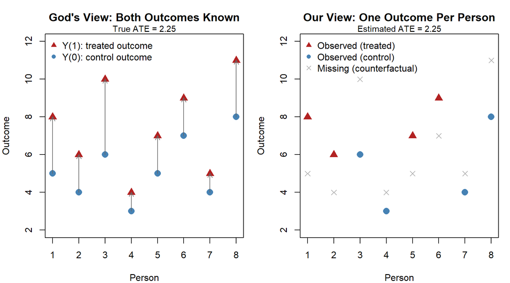

```r
# ----- Build a toy population of 8 people -----
n_fp <- 8
people <- data.frame(
  id    = 1:n_fp,
  Y1    = c(8, 6, 10, 4, 7, 9, 5, 11),
  Y0    = c(5, 4, 6, 3, 5, 7, 4, 8),
  tau   = NA
)
people$tau <- people$Y1 - people$Y0

# ----- Randomly assign 4 to treatment -----
treated_ids <- sample(1:n_fp, 4)
people$Z <- ifelse(people$id %in% treated_ids, 1, 0)
people$Y_obs <- ifelse(people$Z == 1, people$Y1, people$Y0)
people$Y_missing <- ifelse(people$Z == 1, people$Y0, people$Y1)

# ----- Plot: what God sees vs what we see -----
par(mfrow = c(1, 2), mar = c(4, 4, 3, 1))

# Left: GOD'S VIEW
plot(1:n_fp, people$Y1, pch = 17, col = "firebrick", cex = 1.5, ylim = c(2, 12),
     xlab = "Person", ylab = "Outcome", main = "God's View: Both Outcomes Known")
points(1:n_fp, people$Y0, pch = 16, col = "steelblue", cex = 1.5)
arrows(1:n_fp, people$Y0, 1:n_fp, people$Y1, length = 0.08, col = "gray40")
legend("topleft", legend = c("Y(1): treated outcome", "Y(0): control outcome"),
       pch = c(17, 16), col = c("firebrick", "steelblue"), bty = "n")
mtext(paste("True ATE =", round(mean(people$tau), 2)), side = 3, line = 0, cex = 0.9)

# Right: RESEARCHER'S VIEW
plot(1:n_fp, people$Y_obs, pch = ifelse(people$Z == 1, 17, 16),
     col = ifelse(people$Z == 1, "firebrick", "steelblue"),
     cex = 1.5, ylim = c(2, 12),
     xlab = "Person", ylab = "Outcome", main = "Our View: One Outcome Per Person")
points(1:n_fp, people$Y_missing, pch = 4, col = "gray70", cex = 1.2)
legend("topleft",
       legend = c("Observed (treated)", "Observed (control)", "Missing (counterfactual)"),
       pch = c(17, 16, 4), col = c("firebrick", "steelblue", "gray70"), bty = "n")
tau_hat_fp <- mean(people$Y_obs[people$Z == 1]) - mean(people$Y_obs[people$Z == 0])
mtext(paste("Estimated ATE =", round(tau_hat_fp, 2)), side = 3, line = 0, cex = 0.9)
```

**What you see:** The left panel is what we wish we had – both potential outcomes for everyone. The right panel is reality. The gray X’s are the counterfactual outcomes we never get to see. Our estimate bounces around the true ATE depending on which randomization we happened to get.

## 5.3 The “Science” vs. the “Assignment”

There are two separate pieces:

1. **The Science** ($\mathcal{S}$): Everyone’s potential outcomes $\{Y_i(1), Y_i(0)\}$. These are **fixed numbers** that are set in stone before the experiment starts. Person 5’s outcome under treatment is some specific number – it is not random. Think of them as tattoos on everyone’s body that you can only partially read.
2. **The Assignment** ($\mathbf{Z}$): The coin flip (or random draw) that decides who gets treated. **This is the ONLY thing that is random in the entire setup.**

This is a big deal because it means all the probability in this framework – the variance formulas, the CLT, the confidence intervals – comes from the randomization, NOT from assuming outcomes follow some distribution.

## 5.4 The Target: Finite-Population Average Treatment Effect (PATE)

Since we can’t get individual treatment effects, we aim for the **average** across everyone:

$$\tau =
\frac{1}{N}\sum_{i=1}^{N}\big[Y_i(1) - Y_i(0)\big]$$

This is a fixed number (not random) because the potential outcomes are fixed.

## 5.5 The Estimator: Difference in Means

$$\hat{\tau} = \bar{Y}_T - \bar{Y}_C =
\frac{1}{n_1}\sum_{i: Z_i=1} Y_i^{\text{obs}} - \frac{1}{n_0}\sum_{i:
Z_i=0} Y_i^{\text{obs}}$$

## 5.6 Neyman’s Framework – The Estimation Approach

Jerzy Neyman developed a framework focused on **estimating** the average treatment effect and quantifying uncertainty.

**Before we dive in, one important idea you need:** In this class, probability does NOT come from assuming outcomes follow a bell curve or any distribution. The outcomes are fixed numbers. The ONLY randomness is the treatment assignment – the coin flip that decides who goes in which group. When we talk about “variance” and “confidence intervals” below, we mean: how much does the estimate bounce around if you re-did the randomization? This is called the **design-based** or **finite-population** approach, and it is different from what you learned in intro stats (where randomness comes from sampling from a big population). We will make this contrast precise later in this section.

### Unbiasedness

Under a completely randomized design:

$$\mathbb{E}[\hat{\tau}] =
\tau$$

**Translation:** If you could repeat the experiment many times (re-randomizing each time), the average of all your estimates would be the true treatment effect.

### Visualizing Unbiasedness: The Estimate Bounces, but Centers on Truth

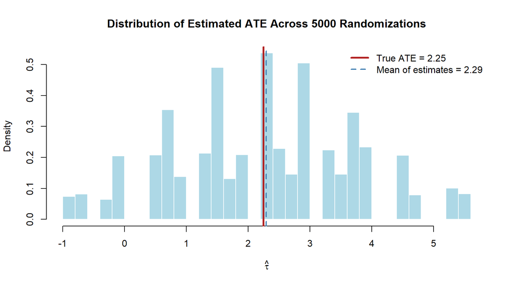

```r
# ----- Same 8 people, repeat the experiment 5000 times -----
n_ub <- 8
Y1_ub <- c(8, 6, 10, 4, 7, 9, 5, 11)
Y0_ub <- c(5, 4, 6,  3, 5, 7, 4, 8)
true_ate_ub <- mean(Y1_ub - Y0_ub)

n_sims <- 5000
estimates_ub <- numeric(n_sims)

for (s in 1:n_sims) {
  Z <- rep(0, n_ub)
  Z[sample(1:n_ub, 4)] <- 1
  Y_obs <- ifelse(Z == 1, Y1_ub, Y0_ub)
  estimates_ub[s] <- mean(Y_obs[Z == 1]) - mean(Y_obs[Z == 0])
}

# ----- Histogram -----
hist(estimates_ub, breaks = 30, col = "lightblue", border = "white",
     main = "Distribution of Estimated ATE Across 5000 Randomizations",
     xlab = expression(hat(tau)), probability = TRUE)
abline(v = true_ate_ub, col = "firebrick", lwd = 3, lty = 1)
abline(v = mean(estimates_ub), col = "steelblue", lwd = 2, lty = 2)
legend("topright",
       legend = c(
         paste("True ATE =", round(true_ate_ub, 2)),
         paste("Mean of estimates =", round(mean(estimates_ub), 2))
       ),
       col = c("firebrick", "steelblue"), lwd = c(3, 2), lty = c(1, 2), bty = "n")
```

**What you see:** Each bar is a possible estimate. Some are too high, some too low. But the CENTER of the distribution lands on the true ATE (red line). That is unbiasedness.

**The mechanism:** Randomization makes each person equally likely to be in the treated group. So the treated group mean is an unbiased estimate of $\bar{Y}(1)$, and the control group mean is an unbiased estimate of $\bar{Y}(0)$. No modeling assumptions needed.

### How much does the estimate bounce around? (Neyman’s Exact Variance)

First, some building blocks. Define these **finite-population variances**:

$$S_1^2 =
\frac{1}{N-1}\sum_{i=1}^{N}\big(Y_i(1) - \bar{Y}(1)\big)^2
\quad\text{(spread of treated potential outcomes)}$$

$$S_0^2 =
\frac{1}{N-1}\sum_{i=1}^{N}\big(Y_i(0) - \bar{Y}(0)\big)^2
\quad\text{(spread of control potential outcomes)}$$

$$S_\tau^2 =
\frac{1}{N-1}\sum_{i=1}^{N}(\tau_i - \tau)^2 \quad\text{(treatment
effect heterogeneity)}$$

Think of $S_\tau^2$: if a drug lowers blood pressure by exactly 10 points for everyone, $S_\tau^2 = 0$ (constant effect). If it lowers by 20 for some and does nothing for others, $S_\tau^2$ is large.

**Neyman’s exact variance formula:**

$$\text{Var}(\hat{\tau}) =
\frac{S_1^2}{n_1} + \frac{S_0^2}{n_0} - \frac{S_\tau^2}{N}$$

**Read it in pieces:**

- $S_1^2 / n_1$: Sampling noise from the treated group. More people = less noise.
- $S_0^2 / n_0$: Same for control.
- $-S_\tau^2 / N$: When treatment effects vary a lot, the variance is actually *smaller*. Why? Because heterogeneous effects create a negative correlation between $\bar{Y}_T$ and $\bar{Y}_C$. When the high-$\tau$ people land in treated, $\bar{Y}_T$ goes up but their absence pushes $\bar{Y}_C$ down. The difference doesn’t move as much.

### The problem with $S_\tau^2$ (and $S_{10}$)

To compute $S_\tau^2$, you need $\tau_i = Y_i(1) - Y_i(0)$ for every person. But that means seeing both their treated AND untreated outcome – which is the fundamental problem again. You never have both, so you can never compute $S_\tau^2$ directly.

**There is an identity that links these things:**

$$S_\tau^2 = S_1^2 + S_0^2 -
2S_{10}$$

where $S_{10}$ is the covariance between a person’s treated outcome and their control outcome: do people who do well under treatment also do well without it? In math: $S_{10} = \frac{1}{N-1}\sum_{i=1}^{N}\big(Y_i(1) - \bar{Y}(1)\big)\big(Y_i(0) - \bar{Y}(0)\big)$.

**Why $S_{10}$ is forever unknowable:** To compute it, you need to see both $Y_i(1)$ and $Y_i(0)$ for the SAME person. You only ever see one. So $S_{10}$ is a number that exists in theory but can never be calculated from data. This means $S_\tau^2$ is also forever unknown.

**Alternate form of Neyman’s variance (using $S_{10}$):** Substituting $S_\tau^2 = S_1^2 + S_0^2 - 2S_{10}$:

$$\text{Var}(\hat{\tau}) = \frac{n_0}{n_1
N}S_1^2 + \frac{n_1}{n_0 N}S_0^2 + \frac{2}{N}S_{10}$$

Same variance, different form. Makes the role of $S_{10}$ explicit.

### The conservative workaround – and WHY it is ALWAYS valid

**Step 1:** $S_\tau^2$ is a variance. Variances are sums of squared deviations. Squares are always non-negative. Therefore: $S_\tau^2 \ge 0$.

**Step 2:** Since $S_\tau^2 \ge 0$, the term $-S_\tau^2/N \le 0$. So:

$$\text{Var}(\hat{\tau}) =
\frac{S_1^2}{n_1} + \frac{S_0^2}{n_0} - \frac{S_\tau^2}{N} \le
\frac{S_1^2}{n_1} + \frac{S_0^2}{n_0}$$

**Step 3:** We CAN estimate $S_1^2$ and $S_0^2$ from the data:

$$s_1^2 =
\frac{1}{n_1-1}\sum_{i:Z_i=1}(Y_i^{\text{obs}} - \bar{Y}_T)^2, \quad
s_0^2 = \frac{1}{n_0-1}\sum_{i:Z_i=0}(Y_i^{\text{obs}} -
\bar{Y}_C)^2$$

**Step 4: Neyman’s conservative variance estimator:**

$$\widehat{\text{Var}}(\hat{\tau}) =
\frac{s_1^2}{n_1} + \frac{s_0^2}{n_0}$$

This **overestimates** the true variance because it pretends $S_\tau^2 = 0$.

### Visualizing: Exact vs Conservative Variance

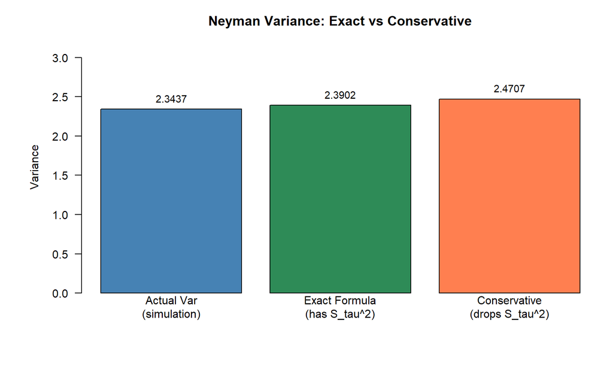

```r
# ----- Population with heterogeneous treatment effects -----
N_nv <- 200
Y0_nv <- rnorm(N_nv, mean = 50, sd = 10)
tau_nv <- rnorm(N_nv, mean = 5, sd = 4)  # heterogeneous effects
Y1_nv <- Y0_nv + tau_nv
true_ate_nv <- mean(tau_nv)

S1_sq <- var(Y1_nv); S0_sq <- var(Y0_nv); S_tau_sq <- var(tau_nv)
n1_nv <- 100; n0_nv <- 100

exact_var    <- S1_sq / n1_nv + S0_sq / n0_nv - S_tau_sq / N_nv
conserv_var  <- S1_sq / n1_nv + S0_sq / n0_nv

# simulate to confirm
n_sims_nv <- 5000
ests_nv <- numeric(n_sims_nv)
var_ests_nv <- numeric(n_sims_nv)

for (s in 1:n_sims_nv) {
  idx_t <- sample(1:N_nv, n1_nv)
  Z <- rep(0, N_nv); Z[idx_t] <- 1
  Y_obs <- ifelse(Z == 1, Y1_nv, Y0_nv)
  ests_nv[s] <- mean(Y_obs[Z == 1]) - mean(Y_obs[Z == 0])
  var_ests_nv[s] <- var(Y_obs[Z == 1]) / n1_nv + var(Y_obs[Z == 0]) / n0_nv
}

par(mar = c(6, 6, 3, 1))
vals_nv <- c(var(ests_nv), exact_var, mean(var_ests_nv))
names(vals_nv) <- c("Actual Var\n(simulation)", "Exact Formula\n(has S_tau^2)", "Conservative\n(drops S_tau^2)")
bp <- barplot(vals_nv, col = c("steelblue", "seagreen", "coral"),
        main = "Neyman Variance: Exact vs Conservative",
        ylab = "Variance", las = 1, ylim = c(0, max(vals_nv) * 1.3))
text(bp, vals_nv, labels = round(vals_nv, 4), pos = 3, cex = 0.9)
```

**What you see:** The coral bar (conservative) is always taller than the green bar (exact). The gap is $S_\tau^2/N$. The conservative estimator overestimates variance, which makes CIs wider than needed – but never too narrow.

### When is the conservative estimator exact?

When $S_\tau^2 = 0$, meaning the treatment effect is **constant** – the same for everyone: $Y_i(1) = Y_i(0) + \tau$ for all $i$.

### Visualizing: Constant vs Heterogeneous Effects

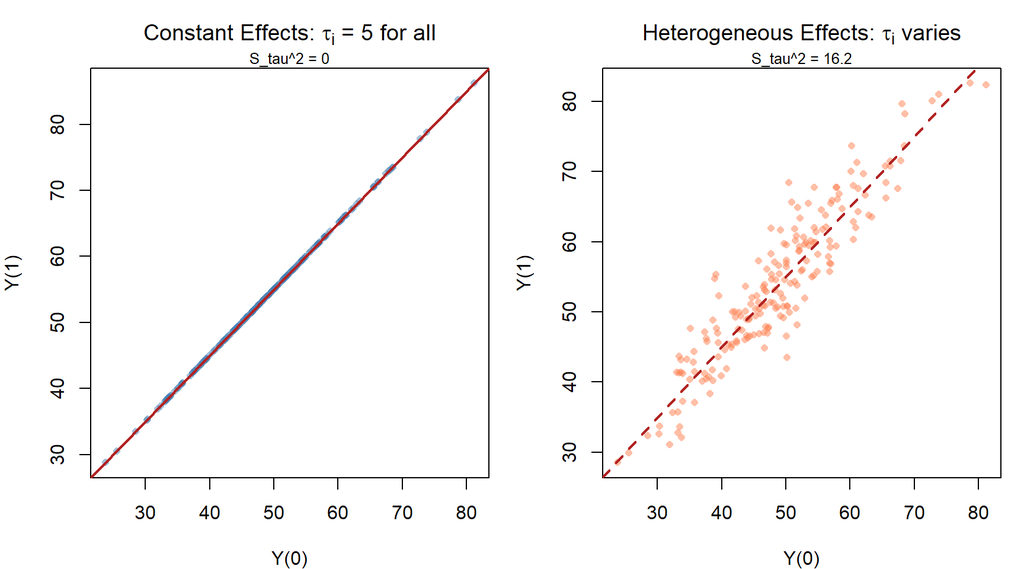

```r
N_ch <- 200
Y0_ch <- rnorm(N_ch, 50, 10)

par(mfrow = c(1, 2), mar = c(4, 4, 3, 1))

# Constant effects
Y1_const <- Y0_ch + 5
tau_const <- Y1_const - Y0_ch
plot(Y0_ch, Y1_const, pch = 16, col = adjustcolor("steelblue", 0.5), cex = 0.8,
     main = expression("Constant Effects: " * tau[i] * " = 5 for all"),
     xlab = "Y(0)", ylab = "Y(1)")
abline(a = 5, b = 1, col = "firebrick", lwd = 2)
mtext(paste("S_tau^2 =", round(var(tau_const), 4)), side = 3, line = 0, cex = 0.8)

# Heterogeneous effects
tau_hetero_ch <- rnorm(N_ch, 5, 4)
Y1_hetero <- Y0_ch + tau_hetero_ch
plot(Y0_ch, Y1_hetero, pch = 16, col = adjustcolor("coral", 0.5), cex = 0.8,
     main = expression("Heterogeneous Effects: " * tau[i] * " varies"),
     xlab = "Y(0)", ylab = "Y(1)")
abline(a = 5, b = 1, col = "firebrick", lwd = 2, lty = 2)
mtext(paste("S_tau^2 =", round(var(tau_hetero_ch), 2)), side = 3, line = 0, cex = 0.8)
```

**What you see:** Left: under constant effects, every person’s Y(1) is exactly 5 above their Y(0) – all points on the line. $S_\tau^2 = 0$, conservative estimator is exact. Right: with heterogeneous effects, points scatter. $S_\tau^2 > 0$, conservative estimator overestimates.

**Check it with the identity:** If effects are constant, adding a constant to every value doesn’t change the spread, so $S_1^2 = S_0^2$. Also $Y_i(1)$ moves in perfect lockstep with $Y_i(0)$, so $S_{10} = S_1^2$. Plug in: $S_\tau^2 = S_1^2 + S_1^2 - 2S_1^2 = 0$.

### The 95% Confidence Interval – WHY It Covers 95%

OK so we have an estimate ($\hat{\tau}$) and we know how much it bounces around (the variance formula). How do we turn that into a confidence interval? We need one more ingredient: a reason to believe the distribution of $\hat{\tau}$ is bell-shaped. That reason is the Finite-Population CLT – a theorem that says “if you randomly shuffle people into two groups enough times, the distribution of the difference in means looks like a bell curve.” Here is the full logic:

$$\hat{\tau} \pm
1.96\sqrt{\widehat{\text{Var}}(\hat{\tau})}$$

**The logic chain (three pieces):**

**PIECE 1: The Finite-Population CLT.** This is the key theoretical result. Under complete randomization, as the sample size grows:

$$\frac{\hat{\tau} -
\tau}{\sqrt{\text{Var}(\hat{\tau})}} \xrightarrow{d} N(0,1)$$

The distribution of $\hat{\tau}$ across all possible randomizations is approximately a bell curve centered at $\tau$. The randomness comes purely from which $n_1$ people out of $N$ happen to get assigned to treatment – NOT from assuming outcomes are normally distributed.

**PIECE 2: The standard error quantifies the WIDTH of that bell curve.** We estimate it with $\sqrt{s_1^2/n_1 + s_0^2/n_0}$, which is **too big** (because we dropped $-S_\tau^2/N$).

**PIECE 3: Putting it together.** For a standard normal, 95% of the mass is within $\pm 1.96$ SDs. Our SE is too big, so our interval is wider than needed, catching the true value **more often** than 95%:

$$\Pr(\tau \in \text{CI}) \ge
95\%$$

### Visualizing the 95% CI Coverage

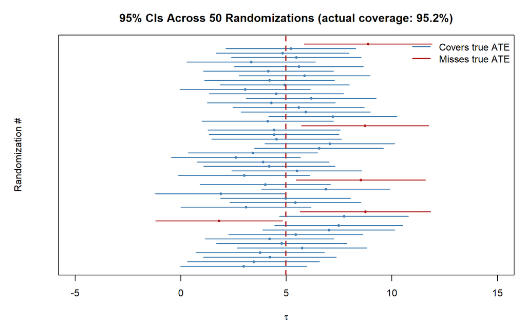

```r
# Compute CIs across many randomizations, check how often they cover tau
covers_ci <- logical(n_sims_nv)

for (s in 1:n_sims_nv) {
  idx_t <- sample(1:N_nv, n1_nv)
  Z <- rep(0, N_nv); Z[idx_t] <- 1
  Y_obs <- ifelse(Z == 1, Y1_nv, Y0_nv)
  tau_hat <- mean(Y_obs[Z == 1]) - mean(Y_obs[Z == 0])
  se_hat <- sqrt(var(Y_obs[Z == 1]) / n1_nv + var(Y_obs[Z == 0]) / n0_nv)
  ci_lo <- tau_hat - 1.96 * se_hat
  ci_hi <- tau_hat + 1.96 * se_hat
  covers_ci[s] <- (true_ate_nv >= ci_lo) & (true_ate_nv <= ci_hi)
}

coverage <- mean(covers_ci)

# Show first 50 CIs
par(mar = c(4, 5, 3, 1))
show_n <- 50
plot(NA, xlim = c(-5, 15), ylim = c(1, show_n), yaxt = "n",
     xlab = expression(tau), ylab = "Randomization #",
     main = paste0("95% CIs Across 50 Randomizations (actual coverage: ",
                   round(coverage * 100, 1), "%)"))

for (s in 1:show_n) {
  idx_t <- sample(1:N_nv, n1_nv)
  Z <- rep(0, N_nv); Z[idx_t] <- 1
  Y_obs <- ifelse(Z == 1, Y1_nv, Y0_nv)
  tau_hat <- mean(Y_obs[Z == 1]) - mean(Y_obs[Z == 0])
  se_hat <- sqrt(var(Y_obs[Z == 1]) / n1_nv + var(Y_obs[Z == 0]) / n0_nv)
  ci_lo <- tau_hat - 1.96 * se_hat
  ci_hi <- tau_hat + 1.96 * se_hat
  hit <- (true_ate_nv >= ci_lo) & (true_ate_nv <= ci_hi)
  segments(ci_lo, s, ci_hi, s, col = ifelse(hit, "steelblue", "firebrick"), lwd = 1.5)
  points(tau_hat, s, pch = 16, cex = 0.6, col = ifelse(hit, "steelblue", "firebrick"))
}
abline(v = true_ate_nv, col = "firebrick", lwd = 2, lty = 2)
legend("topright", legend = c("Covers true ATE", "Misses true ATE"),
       col = c("steelblue", "firebrick"), lwd = 2, bty = "n")
```

**What you see:** Each horizontal bar is a CI from one randomization. Blue bars cover the truth; red bars miss. Because we overestimate the SE, coverage is above 95%.

**Summary of the logic chain:**

1. Randomization + unbiasedness centers $\hat{\tau}$ around $\tau$
2. The finite-population CLT says the distribution is approximately bell-shaped
3. For a normal distribution, $\pm 1.96$ SDs covers 95%
4. We overestimate the SD (because $S_\tau^2 \ge 0$ always), so we get $\ge$ 95% coverage
5. This works for ANY population, ANY treatment effect distribution

### Finite-Population CLT vs. i.i.d. CLT (know the contrast)

There are two completely different reasons why the bell curve shows up. The exam may ask you to explain the difference.

**Finite-Population CLT (FP-CLT) – the one WE use in this class:**

- Everyone’s potential outcomes ($Y_i(1)$ and $Y_i(0)$) are **fixed numbers** that don’t change. They are like heights written on everyone’s forehead.
- The **only** thing that is random is the coin flip that decides who gets treated.
- Because treatment assignment is just a random shuffle of $N$ people into two groups, $\hat{\tau}$ is a sum of random terms: $\hat{\tau} = \sum a_i Z_i + b$. The $a_i$ and $b$ are constants (determined by the fixed potential outcomes).
- As long as no single person dominates the variance and both groups are a reasonable fraction of $N$, the FP-CLT says the distribution of $\hat{\tau}$ is approximately bell-shaped.
- Works with a **finite** group of people – no need to pretend they came from some giant superpopulation.

**i.i.d. CLT (Classical CLT) – what you learned in intro stats:**

- People are **random draws** from some giant (infinite) population.
- Everything is random – the outcomes, the covariates, the treatment.
- The bell curve shows up because you are averaging many independent random things.
- Requires assuming a probability model for outcomes (like “outcomes are normally distributed”).

|  | FP-CLT (this class) | i.i.d. CLT (intro stats) |
| --- | --- | --- |
| What is random? | Only who gets treated ($Z_i$) | Everything: $Y_i, X_i, Z_i$ |
| What is fixed? | Everyone’s potential outcomes | Nothing – all are random draws |
| Population | Finite, specific group of $N$ people | Infinite superpopulation |
| Where does variance come from? | The random treatment assignment | Random sampling from the population |

### Neyman vs. the classical two-sample t-test

|  | Neyman’s approach | Classical t-test |
| --- | --- | --- |
| What is random? | Only the treatment **assignment** | The **outcomes** themselves |
| Are outcomes fixed or random? | Fixed | Random (draws from distributions) |
| Where does the variance formula come from? | The randomization mechanism | A probability model for outcomes |
| Does it pool variances? | No | Often yes |
| Does it need normality? | No | Yes (or large sample) |

## 5.7 Fisher’s Framework – The Testing Approach

R.A. Fisher had a different approach. Instead of trying to estimate the treatment effect, he asked: **“Can I prove that the treatment did anything at all?”**

### Fisher’s Sharp Null Hypothesis

$$H_0: Y_i(1) = Y_i(0) \quad \text{for ALL
} i$$

The treatment has **absolutely zero effect on every single person**. Under $H_0$, all potential outcomes are known ($= Y_i^{\text{obs}}$).

**Sharp null vs. weak null (important distinction):**

- **Sharp null:** $H_0: Y_i(1) = Y_i(0)$ for ALL $i$. Fully specifies every missing potential outcome. Fisher’s test requires this.
- **Weak null:** $H_0: \tau = 0$ (the *average* effect is zero). Does NOT tell you individual potential outcomes – some people might benefit and others be harmed, as long as it averages to zero. You CANNOT run a randomization test with the weak null because you don’t know the missing outcomes.

Neyman’s framework targets the weak null (estimating/testing $\tau = 0$). Fisher’s framework requires the sharp null.

### The Randomization Test

1. Pick a test statistic $T$ (e.g., difference in means)
2. Compute $T_{\text{obs}}$ from your actual data
3. List all $\binom{N}{n_1}$ possible assignments
4. For each one, compute $T$ (using the same outcomes, since under $H_0$ they don’t change)
5. p-value = fraction of assignments where $|T| \ge |T_{\text{obs}}|$

**Why this is amazing:** Exact (no approximations), requires zero distributional assumptions, works in any sample size. Its validity depends ONLY on the randomization being real.

### Visualizing Fisher’s Randomization Test

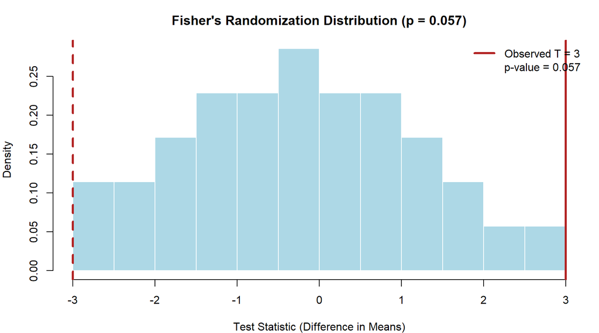

```r
# ----- Small experiment: 8 people, 4 treated -----
Y_obs_f <- c(8, 6, 7, 9, 4, 6, 5, 3)
N_f <- 8; n1_f <- 4

Z_obs_f <- c(1, 1, 1, 1, 0, 0, 0, 0)
T_obs_f <- mean(Y_obs_f[Z_obs_f == 1]) - mean(Y_obs_f[Z_obs_f == 0])

# Under sharp null: enumerate all choose(8,4) = 70 assignments
combos <- combn(1:N_f, n1_f)
T_all <- apply(combos, 2, function(idx) {
  mean(Y_obs_f[idx]) - mean(Y_obs_f[-idx])
})

p_value_f <- mean(abs(T_all) >= abs(T_obs_f))

# ----- Histogram of randomization distribution -----
par(mar = c(4, 4, 3, 1))
hist(T_all, breaks = 20, col = "lightblue", border = "white",
     main = paste0("Fisher's Randomization Distribution (p = ", round(p_value_f, 3), ")"),
     xlab = "Test Statistic (Difference in Means)", probability = TRUE)
abline(v = T_obs_f, col = "firebrick", lwd = 3)
abline(v = -T_obs_f, col = "firebrick", lwd = 3, lty = 2)
legend("topright",
       legend = c(paste("Observed T =", round(T_obs_f, 2)),
                  paste("p-value =", round(p_value_f, 3))),
       col = c("firebrick", NA), lwd = c(3, NA), bty = "n")
```

**What you see:** Under the sharp null, we know every possible test statistic value. The red line is what we observed. The p-value is the fraction at or beyond the red lines. No normality assumption needed.

**One-sided vs. two-sided p-values:** For a two-sided test, you compute $p = \Pr(|T| \ge |T_{\text{obs}}|)$. Some textbooks compute a one-sided $p$ and double it, but **doubling is NOT always valid** because the randomization distribution may not be symmetric. Always compute the two-sided p-value directly from the proportion of $|T| \ge |T_{\text{obs}}|$.

**The minimum possible p-value** in a randomization test is $1/\binom{N}{n_1}$. For example, with $N = 6$ and $n_1 = 3$, the smallest possible p-value is $1/20 = 0.05$. You literally cannot get a p-value below this no matter how extreme the result. So with very small samples, some significance levels (like 0.01) are impossible to achieve.

**Type I error, Type II error, Power:** Type I error = rejecting $H_0$ when it is true (probability $\alpha$, the significance level). Type II error = failing to reject when $H_0$ is false. Power = $1 - \text{Type II error rate}$ = probability of correctly detecting a real effect.

**Randomization tests are NOT the same as permutation tests.** They look identical when you run them on a computer – same calculation. But the reasoning behind them is different. A permutation test assumes the data are exchangeable (a statistical assumption about the distribution). A randomization test doesn’t assume anything about the data – it works because YOU actually randomized the treatment. The validity comes from the experiment design, not from a model.

## 5.8 Constant Additive Treatment Effects

This means the treatment does the exact same thing to everyone – adds exactly $\tau$ to every person’s outcome:

$$Y_i(1) = Y_i(0) + \tau \quad \text{for
all } i$$

If a drug lowers blood pressure by exactly 10 for everyone (not 15 for some and 5 for others), that is a constant additive effect.

### Testing a specific value of $\tau$

Suppose someone claims the treatment effect is $\tau_0 = 5$. Can you test that? Yes:

1. Subtract the claimed effect from every treated person’s outcome: $Y_i^{(\tau_0)} = Y_i^{\text{obs}} - Z_i \cdot \tau_0$
2. If the claim is right, these adjusted outcomes should show NO treatment effect (because you subtracted it out)
3. Run Fisher’s randomization test on the adjusted data. If the p-value is small, the claim $\tau = \tau_0$ is rejected.

### Confidence Intervals by Inversion

This is a cool trick. Try a whole range of possible $\tau_0$ values: 1, 2, 3, 4, … For each one, do the test above. Collect all the values that were NOT rejected:

$$\mathcal{C}_{1-\alpha} = \{\tau_0 :
p(\tau_0) > \alpha\}$$

That set IS your confidence interval. It contains every value of the treatment effect that is consistent with your data. Properties: exact (not approximate), works in any sample size, no normality needed.

## 5.9 Choice of Test Statistics

**Difference in means:** Best when outcomes are well-behaved. Sensitive to outliers.

**Rank-based (Wilcoxon):** Uses ranks instead of raw values. More robust to outliers and skewed data.

Both give exact p-values from the randomization distribution.

## 5.10 Neyman vs. Fisher: Summary

|  | Neyman | Fisher |
| --- | --- | --- |
| Goal | **Estimate** $\tau$ (number + CI) | **Test** whether $\tau = 0$ (p-value) |
| Assumes constant effects? | No | Sharp null or constant effects |
| Key output | $\hat{\tau} \pm \text{margin of error}$ | p-value |
| Type of inference | Asymptotic (CLT-based) | Exact (enumerate all assignments) |

Both are valid under randomization. They answer slightly different questions.

# 6. Addendum: Using Regression Inside an Experiment

## 6.1 The Puzzle

We just showed that $\hat{\tau} = \bar{Y}_T - \bar{Y}_C$ is already unbiased in a randomized experiment. So why bother running a regression?

**Answer: Precision.** Regression doesn’t change WHAT you are estimating – it makes the estimate **less noisy**.

## 6.2 How It Helps

In any particular randomization, there will be some accidental imbalances (maybe the treated group happens to be slightly older). These imbalances add noise.

Regression strips out the part of the outcome that is predictable from covariates, leaving a cleaner comparison. Think of it like noise-cancelling headphones for your estimate.

## 6.3 Key Facts

1. **Still unbiased**, even if the regression model is wrong. In a randomized experiment, $\hat{\tau}_{\text{reg}}$ is unbiased for $\tau$ regardless of whether the linear model is correctly specified. This is because randomization makes $Z$ mean-independent of $X$ (see Section 3.7), so the FWL residual $\tilde{Z}$ is uncorrelated with any function of $X$, including omitted nonlinearities. The bias term $\sum w_i g(X_i) \approx 0$ by the randomization.
2. **Variance is smaller** (or at worst, the same) compared to the simple difference in means. The better covariates predict the outcome, the bigger the improvement.
3. **Does not change the estimand.** You are still estimating the same $\tau$.

## 6.4 The Bottom Line

> In an experiment, regression adjustment is like blocking after the fact. It removes noise by accounting for covariate imbalances that arose by chance. It **refines** an already valid design – it does not rescue a bad one.

# 7. Week 5: Observational Studies and Matching

## 7.1 When You Can’t Randomize

Often you just can’t randomly assign treatment:

- You can’t randomly make people smoke to study lung cancer (ethics)
- You can’t randomly assign kids to rich vs. poor families (impossible)
- You can’t randomize past events (the data already exists)

But you still want to know the causal effect. What do you do?

## 7.2 The Core Idea

> An observational study is an attempt to **reconstruct the balance** that randomization would have created.

Since you can’t randomize, you try to find treated and control people who **look the same** on their background characteristics.

**Three principles:**

1. **Separate design from analysis.** Figure out how to make the groups comparable **before** you look at the outcomes.
2. **Construct comparable groups.** Use matching (or other techniques).
3. **Covariates refine, not rescue.** Covariates can improve a decent comparison, but they can’t save a fundamentally flawed one.

## 7.3 Matching

**What it is:** Find pairs (or sets) of people – one treated, one control – who have similar background characteristics. Discard everyone who doesn’t have a good match. Then compare outcomes within the matched sample.

**It is a design tool, not an analysis tool.** Matching creates a new, better dataset.

### The matched estimator

After matching, the treatment effect estimate is simply the average within-pair difference:

$$\hat{\tau}_{\text{match}} =
\frac{1}{n_M} \sum_{i: Z_i=1} [Y_i - Y_{j(i)}]$$

where $j(i)$ is the matched control for treated person $i$, and $n_M$ is the number of matched pairs. Under SUTVA, ignorability, and good covariate balance, this is approximately unbiased for $\tau$.

### Types of Matching

**Exact matching:** Only match people with identical covariates. Perfect balance, but impossible in practice with continuous covariates.

**Nearest-neighbor matching:** For each treated person, find the closest control.

**Mahalanobis distance matching:** A smart distance that accounts for scale and correlation.

**Propensity score matching:** Match on a single number summarizing the probability of being treated.

**Optimal matching:** Minimizes total distance across ALL pairs simultaneously.

### Visualizing Matching: Before and After

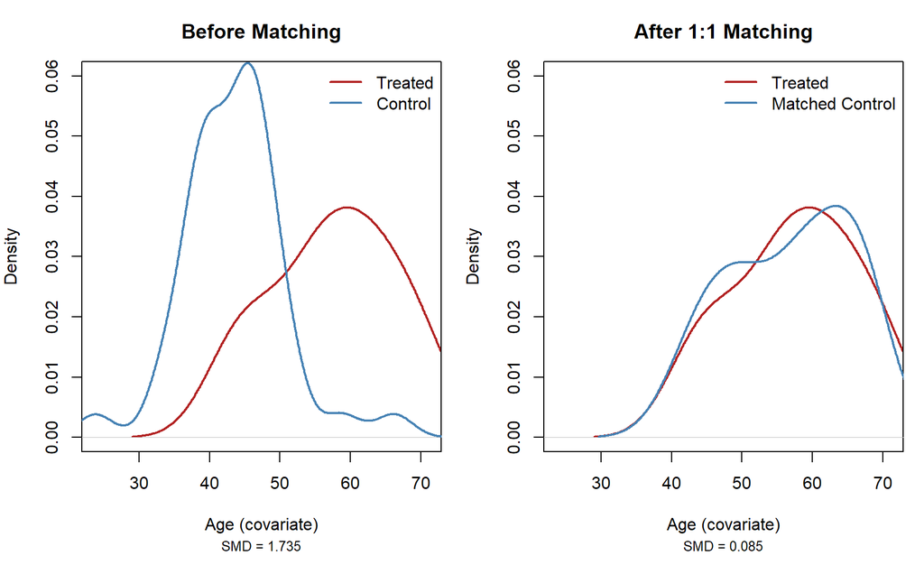

```r
# ----- Simple 1D matching example -----
n_t_m <- 15; n_c_m <- 40
X_t_m <- rnorm(n_t_m, 55, 8)
X_c_m <- rnorm(n_c_m, 45, 8)

# Nearest-neighbor matching
matched_c_m <- numeric(n_t_m)
for (i in 1:n_t_m) {
  dists <- abs(X_c_m - X_t_m[i])
  matched_c_m[i] <- which.min(dists)
}
X_c_matched_m <- X_c_m[matched_c_m]

par(mfrow = c(1, 2), mar = c(5.5, 4, 3, 1))

# Before matching
plot(density(X_t_m), col = "firebrick", lwd = 2, xlim = range(c(X_t_m, X_c_m)),
     main = "Before Matching", xlab = "Age (covariate)", ylim = c(0, 0.06))
lines(density(X_c_m), col = "steelblue", lwd = 2)
legend("topright", legend = c("Treated", "Control"),
       col = c("firebrick", "steelblue"), lwd = 2, bty = "n")
smd_before_m <- (mean(X_t_m) - mean(X_c_m)) / sqrt((var(X_t_m) + var(X_c_m)) / 2)
mtext(paste("SMD =", round(smd_before_m, 3)), side = 1, line = 4, cex = 0.8)

# After matching
plot(density(X_t_m), col = "firebrick", lwd = 2, xlim = range(c(X_t_m, X_c_m)),
     main = "After 1:1 Matching", xlab = "Age (covariate)", ylim = c(0, 0.06))
lines(density(X_c_matched_m), col = "steelblue", lwd = 2)
legend("topright", legend = c("Treated", "Matched Control"),
       col = c("firebrick", "steelblue"), lwd = 2, bty = "n")
smd_after_m <- (mean(X_t_m) - mean(X_c_matched_m)) / sqrt((var(X_t_m) + var(X_c_matched_m)) / 2)
mtext(paste("SMD =", round(smd_after_m, 3)), side = 1, line = 4, cex = 0.8)
```

**What you see:** Before matching, the age distributions are shifted apart (large SMD). After matching, they overlap closely (SMD near 0). Matching created comparable groups.

## 7.4 How Do You Know If Matching Worked?

### Standardized Mean Difference (SMD)

$$\text{SMD}(X) = \frac{\bar{X}_T -
\bar{X}_C}{s_X}$$

where $s_X = \sqrt{(s_T^2 + s_C^2)/2}$ is the pooled standard deviation.

**Rules of thumb:**

- $|\text{SMD}| < 0.1$: great balance
- $|\text{SMD}| \approx 0.2$: okay but not great
- $|\text{SMD}| > 0.25$: bad

**Why not use a t-test?** Because t-test p-values depend on sample size. With a huge sample, even a tiny, meaningless difference will be “significant.” SMD measures the **actual size** of the imbalance.

### Variance Ratios

$$\text{VR}(X) =
\frac{\text{Var}(X_T)}{\text{Var}(X_C)}$$

Should be close to 1.

### Love Plots

A visual tool. Plot SMDs before and after matching for each covariate. You want to see all the dots move close to zero.

### Visualizing a Love Plot

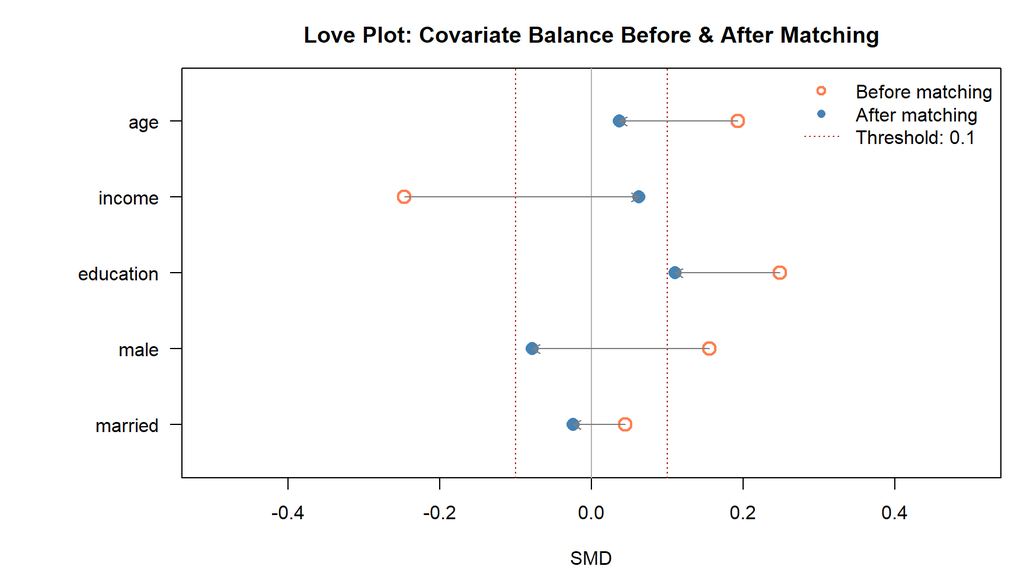

```r
# ----- Multi-covariate observational data -----
N_lp <- 500
covs_lp <- data.frame(
  age       = rnorm(N_lp, 50, 10),
  income    = rnorm(N_lp, 55000, 15000),
  education = rpois(N_lp, 14),
  male      = rbinom(N_lp, 1, 0.5),
  married   = rbinom(N_lp, 1, 0.6)
)

lp_logit <- -2 + 0.03 * covs_lp$age - 0.00001 * covs_lp$income + 0.1 * covs_lp$education +
      0.3 * covs_lp$male + 0.2 * covs_lp$married
Z_lp <- rbinom(N_lp, 1, plogis(lp_logit))

# SMDs before matching
smd_before_lp <- sapply(covs_lp, function(x) {
  (mean(x[Z_lp == 1]) - mean(x[Z_lp == 0])) / sqrt((var(x[Z_lp == 1]) + var(x[Z_lp == 0])) / 2)
})

# PS matching (simple NN on PS)
ps_lp <- fitted(glm(Z_lp ~ ., data = cbind(covs_lp, Z_lp = Z_lp), family = binomial))
t_idx_lp <- which(Z_lp == 1); c_idx_lp <- which(Z_lp == 0)
matched_c_lp <- numeric(length(t_idx_lp))
for (i in seq_along(t_idx_lp)) {
  dists <- abs(ps_lp[c_idx_lp] - ps_lp[t_idx_lp[i]])
  matched_c_lp[i] <- c_idx_lp[which.min(dists)]
}

smd_after_lp <- sapply(covs_lp, function(x) {
  (mean(x[t_idx_lp]) - mean(x[matched_c_lp])) /
    sqrt((var(x[t_idx_lp]) + var(x[matched_c_lp])) / 2)
})

# ----- Love Plot -----
par(mar = c(4, 8, 3, 1))
k_lp <- length(smd_before_lp)
y_pos_lp <- k_lp:1

plot(NA, xlim = c(-0.5, 0.5), ylim = c(0.5, k_lp + 0.5),
     yaxt = "n", xlab = "SMD", ylab = "",
     main = "Love Plot: Covariate Balance Before & After Matching")
axis(2, at = y_pos_lp, labels = names(smd_before_lp), las = 1)
abline(v = 0, lty = 1, col = "gray70")
abline(v = c(-0.1, 0.1), lty = 3, col = "firebrick")

points(smd_before_lp, y_pos_lp, pch = 1, col = "coral", cex = 1.5, lwd = 2)
points(smd_after_lp, y_pos_lp, pch = 16, col = "steelblue", cex = 1.5)
arrows(smd_before_lp, y_pos_lp, smd_after_lp, y_pos_lp, length = 0.08, col = "gray50")

legend("topright", legend = c("Before matching", "After matching", "Threshold: 0.1"),
       pch = c(1, 16, NA), col = c("coral", "steelblue", "firebrick"),
       lty = c(NA, NA, 3), pt.lwd = c(2, 1, NA), bty = "n")
```

## 7.5 Why Matching Reduces Bias

The idea is simple: if your matched pair has very similar background characteristics, then whatever effect those characteristics have on the outcome is basically the same for both people in the pair. So when you subtract their outcomes, the background effect cancels and you are left with mostly just the treatment effect.

Formally, under a model where $Y_i = \tau Z_i + g(X_i) + \varepsilon_i$ (the outcome depends on treatment plus some function of background):

$$\text{Bias} =
\frac{1}{n_M}\sum_{i=1}^{n_M}\big(g(X_i) - g(X_{j(i)})\big)$$

If person $i$ and their match $j(i)$ have similar $X$ values, then $g(X_i) \approx g(X_{j(i)})$ and each pair contributes almost zero bias. The closer the matches, the smaller the bias.

### The Chebyshev-type bias bound

This formula puts a ceiling on how bad the bias can be:

$$|\text{Bias}| \le L\big(|\Delta_X^M| +
2s_D\big)$$

In plain English:

- $L$ = how steeply the outcome changes with $X$. You have no control over this – it is a property of the real world.
- $\Delta_X^M$ = the average gap between matched pairs on $X$. Better matches = smaller gap = you CAN control this.
- $s_D$ = how inconsistent your match quality is across pairs. You CAN control this too.

So the message is: make your matches as close as possible (small $\Delta_X^M$) and as consistently close as possible (small $s_D$), and you keep the bias small.

## 7.6 Exact Balance vs. Near-Fine Balance

**Exact balance:** The treated and control groups have the EXACT same distribution of a covariate (e.g., same % male, same % married). In practice this is hard to pull off for many covariates at once.

**Near-fine balance:** The distributions are close ENOUGH (SMD < 0.1). Not perfect, but good enough for reliable estimates.

**Why you can’t always insist on exact:** Suppose you require exact matching on race. If there are very few treated Black units, you might be forced to pair them with distant controls just to stay within-race – making the match terrible on age, income, etc. **Near-fine balance** is a compromise: it makes sure the overall % of each race is similar across groups, but allows individual pairs to be cross-race if that gives better matches on other variables.

## 7.7 Mahalanobis Distance and the Curse of Dimensionality

$$d_M(X_i, X_j) = \sqrt{(X_i - X_j)^\top
\hat{\Sigma}^{-1} (X_i - X_j)}$$

Regular distance treats all variables the same, which is a problem – a 1-year age difference and a $1 income difference are very different things. Mahalanobis distance fixes this by rescaling each variable by how spread out it is and accounting for correlations between variables. It puts everything on a fair, apples-to-apples scale.

**The curse of dimensionality:** Here is a practical problem. When you have a ton of covariates (age, income, education, health, gender, …), “closest neighbor” stops being actually close. With 20 variables, even the “nearest” control person might be pretty different from the treated person on several of those 20 dimensions. This is why collapsing everything into one number – the propensity score – becomes essential. Instead of matching on 20 things, you match on one number.

**Hybrid approach:** Mahalanobis distance on key covariates + propensity score caliper.

### Composite distance with categorical penalty

Sometimes you have a mix of number-based variables (age, income) and category-based variables (race, gender). You can build a distance that handles both by adding a penalty whenever two people are in different categories:

$$d\big((X_i, W_i), (X_j, W_j)\big) = (X_i
- X_j)^2 + \lambda \cdot \mathbf{1}\{W_i \ne W_j\}$$

The first part is the usual distance on continuous $X$. The second part adds a penalty of $\lambda$ whenever the categories don’t match (e.g., different race). Make $\lambda$ big and the algorithm strongly prefers same-category matches. Make it small and it mostly ignores categories. This is more flexible than requiring exact category matches – it is a “soft preference” you can tune.

### Worked optimal matching example (exam-style)

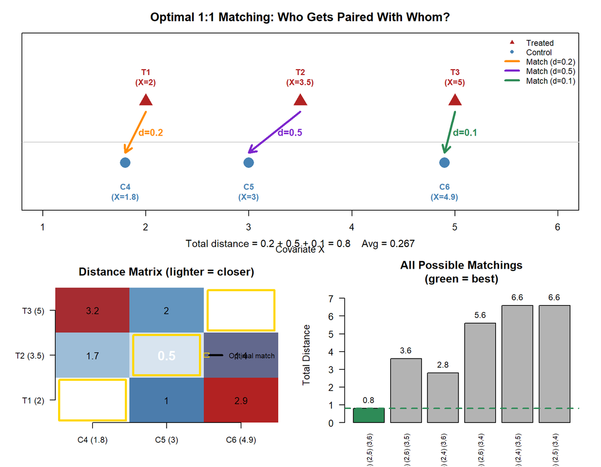

```r
# ----- Data -----
treated <- data.frame(unit = 1:3, X = c(2.0, 3.5, 5.0))
control <- data.frame(unit = 4:6, X = c(1.8, 3.0, 4.9))

# Distance matrix
dist_mat <- outer(treated$X, control$X, function(a, b) abs(a - b))

# Optimal matches (by inspection: minimize total distance)
matches <- data.frame(t_unit = 1:3, c_unit = 4:6,
                      t_x = treated$X, c_x = control$X,
                      dist = c(0.2, 0.5, 0.1))

layout(matrix(c(1, 1, 2, 3), nrow = 2, byrow = TRUE), heights = c(1.2, 1))

# ----- Panel 1: Number line showing units and matches -----
par(mar = c(4, 2, 3, 2))
plot(NA, xlim = c(1, 6), ylim = c(-1.5, 2.5), xlab = "Covariate X", ylab = "",
     yaxt = "n", main = "Optimal 1:1 Matching: Who Gets Paired With Whom?",
     cex.main = 1.3)

# Draw the number line
abline(h = 0, col = "gray80", lwd = 1)

# Plot treated units (top)
points(treated$X, rep(1, 3), pch = 17, col = "firebrick", cex = 2.5)
text(treated$X, rep(1.6, 3),
     labels = paste0("T", treated$unit, "\n(X=", treated$X, ")"),
     col = "firebrick", cex = 0.9, font = 2)

# Plot control units (bottom)
points(control$X, rep(-0.5, 3), pch = 16, col = "steelblue", cex = 2.5)
text(control$X, rep(-1.2, 3),
     labels = paste0("C", control$unit, "\n(X=", control$X, ")"),
     col = "steelblue", cex = 0.9, font = 2)

# Draw match arrows with distance labels
match_cols <- c("darkorange", "purple3", "seagreen")
for (i in 1:3) {
  arrows(matches$t_x[i], 0.75, matches$c_x[i], -0.25,
         col = match_cols[i], lwd = 3, length = 0.12)
  mid_x <- (matches$t_x[i] + matches$c_x[i]) / 2
  text(mid_x + 0.15, 0.25,
       labels = paste0("d=", matches$dist[i]),
       col = match_cols[i], cex = 1, font = 2)
}

legend("topright",
       legend = c("Treated", "Control", paste0("Match (d=", matches$dist, ")")),
       pch = c(17, 16, NA, NA, NA), lwd = c(NA, NA, 3, 3, 3),
       col = c("firebrick", "steelblue", match_cols),
       bty = "n", cex = 0.85)
mtext("Total distance = 0.2 + 0.5 + 0.1 = 0.8    Avg = 0.267", side = 1, line = 2.5, cex = 0.9)

# ----- Panel 2: Distance matrix as a heatmap -----
par(mar = c(4, 5, 3, 2))
image(1:3, 1:3, dist_mat, col = colorRampPalette(c("white", "steelblue", "firebrick"))(20),
      xlab = "", ylab = "", axes = FALSE,
      main = "Distance Matrix (lighter = closer)")
axis(1, at = 1:3, labels = paste0("C", 4:6, " (", control$X, ")"), cex.axis = 0.9)
axis(2, at = 1:3, labels = paste0("T", 1:3, " (", treated$X, ")"), las = 1, cex.axis = 0.9)

# Add distance values to cells
for (i in 1:3) {
  for (j in 1:3) {
    is_match <- (i == j)  # diagonal = optimal match
    text(j, i, round(dist_mat[i, j], 1),
         cex = ifelse(is_match, 1.4, 1),
         font = ifelse(is_match, 2, 1),
         col = ifelse(is_match, "white", "black"))
    if (is_match) {
      rect(j - 0.45, i - 0.45, j + 0.45, i + 0.45, border = "gold", lwd = 3)
    }
  }
}
legend("right", legend = "Optimal match", border = "gold", fill = NA, lwd = 3, bty = "n", cex = 0.8)

# ----- Panel 3: Why this matching is optimal -----
par(mar = c(4, 4, 3, 2))
all_matchings <- list(
  c("(1,4) (2,5) (3,6)", 0.2 + 0.5 + 0.1),
  c("(1,4) (2,6) (3,5)", 0.2 + 1.4 + 2.0),
  c("(1,5) (2,4) (3,6)", 1.0 + 1.7 + 0.1),
  c("(1,5) (2,6) (3,4)", 1.0 + 1.4 + 3.2),
  c("(1,6) (2,4) (3,5)", 2.9 + 1.7 + 2.0),
  c("(1,6) (2,5) (3,4)", 2.9 + 0.5 + 3.2)
)
labels <- sapply(all_matchings, `[[`, 1)
totals <- as.numeric(sapply(all_matchings, `[[`, 2))
cols <- ifelse(totals == min(totals), "seagreen", "gray70")

bp <- barplot(totals, names.arg = labels, col = cols, las = 2, cex.names = 0.7,
              main = "All Possible Matchings\n(green = best)",
              ylab = "Total Distance", ylim = c(0, max(totals) * 1.15))
text(bp, totals, labels = round(totals, 1), pos = 3, cex = 0.9)
abline(h = min(totals), lty = 2, col = "seagreen", lwd = 2)
```

**What you see:** The top panel shows all 6 units on a number line – treated (triangles) on top, control (circles) on bottom – with colored arrows connecting matched pairs. The heatmap shows the full distance matrix (lighter = closer match, gold boxes = the pairs we picked). The bar chart proves this IS the best matching by comparing the total distance of all 6 possible pairings.

## 7.8 1:1 vs. 1:k Matching: The Bias-Variance Trade-off

### Visualizing the Bias-Variance Trade-off

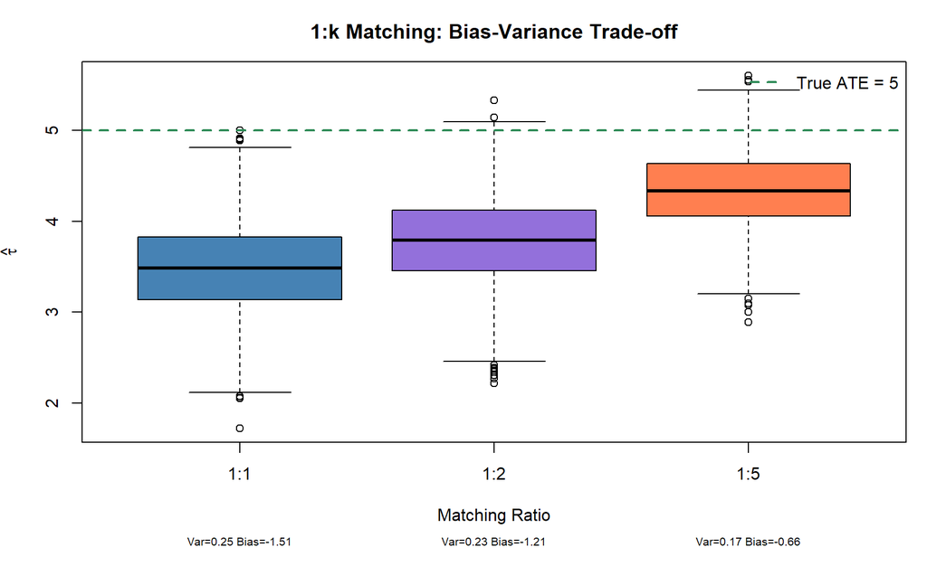

```r
N_t_1k <- 50; N_c_1k <- 200
n_sims_1k <- 2000

X_t_1k <- rnorm(N_t_1k, 55, 8)
X_c_1k <- rnorm(N_c_1k, 45, 8)
Y_c_1k <- 0.5 * X_c_1k + rnorm(N_c_1k, 0, 3)
Y_t_1k <- 0.5 * X_t_1k + 5 + rnorm(N_t_1k, 0, 3)

match_1k <- function(k) {
  ests <- numeric(n_sims_1k)
  for (s in 1:n_sims_1k) {
    t_idx <- sample(1:N_t_1k, 30, replace = FALSE)
    X_t <- X_t_1k[t_idx]; Y_t <- Y_t_1k[t_idx]
    matched_Y <- numeric(30)
    for (i in 1:30) {
      dists <- abs(X_c_1k - X_t[i])
      top_k <- order(dists)[1:k]
      matched_Y[i] <- mean(Y_c_1k[top_k])
    }
    ests[s] <- mean(Y_t - matched_Y)
  }
  return(ests)
}

est_1_1k <- match_1k(1); est_2_1k <- match_1k(2); est_5_1k <- match_1k(5)

par(mar = c(6, 4, 3, 1))
boxplot(list("1:1" = est_1_1k, "1:2" = est_2_1k, "1:5" = est_5_1k),
        col = c("steelblue", "mediumpurple", "coral"),
        main = "1:k Matching: Bias-Variance Trade-off",
        ylab = expression(hat(tau)), xlab = "Matching Ratio")
abline(h = 5, lty = 2, col = "seagreen", lwd = 2)
legend("topright", legend = "True ATE = 5", lty = 2, col = "seagreen", lwd = 2, bty = "n")

for (i in 1:3) {
  ests_i <- list(est_1_1k, est_2_1k, est_5_1k)[[i]]
  mtext(paste0("Var=", round(var(ests_i), 2), " Bias=", round(mean(ests_i) - 5, 2)),
        side = 1, at = i, line = 4.2, cex = 0.65)
}
```

# 8. Week 6: Making Observational Studies Work – Assumptions and Propensity Scores

## 8.1 The Problem: Selection Bias

In observational data, if you just compare treated and untreated groups:

$$\mathbb{E}[Y \mid Z=1] - \mathbb{E}[Y
\mid Z=0] = \underbrace{\mathbb{E}[Y(1) - Y(0) \mid Z=1]}_{\text{ATT}} +
\underbrace{\mathbb{E}[Y(0) \mid Z=1] - \mathbb{E}[Y(0) \mid
Z=0]}_{\text{selection bias}}$$

**How to derive this (exam-ready, the add-and-subtract trick):**

Start with what you can actually compute: $\mathbb{E}[Y \mid Z\!=\!1] - \mathbb{E}[Y \mid Z\!=\!0]$ (average outcome of treated minus average outcome of controls).

Step 1 (SUTVA): Since treated people show us their $Y(1)$ and controls show us their $Y(0)$: $\mathbb{E}[Y \mid Z\!=\!1] = \mathbb{E}[Y(1) \mid Z\!=\!1]$ and $\mathbb{E}[Y \mid Z\!=\!0] = \mathbb{E}[Y(0) \mid Z\!=\!0]$.

Step 2 (the trick): Add and subtract $\mathbb{E}[Y(0) \mid Z\!=\!1]$ – this is “what would have happened to the treated people if they had NOT been treated.” We never see this, but adding and subtracting the same thing is always legal:

$$= \underbrace{\mathbb{E}[Y(1) \mid
Z\!=\!1] - \mathbb{E}[Y(0) \mid Z\!=\!1]}_{\text{ATT: actual treatment
effect on the treated}} + \underbrace{\mathbb{E}[Y(0) \mid Z\!=\!1] -
\mathbb{E}[Y(0) \mid Z\!=\!0]}_{\text{selection bias: treated were
already different}}$$

The **selection bias** is asking: even WITHOUT treatment, would the treated group have had different outcomes than the control group? If yes, your naive comparison is picking up that pre-existing difference on top of the treatment effect.

### Visualizing Selection Bias

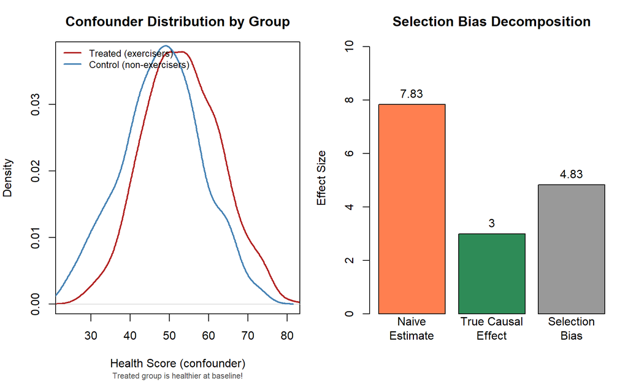

```r
N_sb <- 1000
health <- rnorm(N_sb, 50, 10)  # confounder
Z_sb <- rbinom(N_sb, 1, plogis(-3 + 0.06 * health))  # healthier people exercise more
Y0_sb <- 0.8 * health + rnorm(N_sb, 0, 5)
Y1_sb <- Y0_sb + 3  # TRUE effect = exactly 3
Y_sb <- ifelse(Z_sb == 1, Y1_sb, Y0_sb)

naive_est <- mean(Y_sb[Z_sb == 1]) - mean(Y_sb[Z_sb == 0])
selection_bias <- naive_est - 3

par(mfrow = c(1, 2), mar = c(5, 4, 3, 1))

# Panel 1: confounder distributions
plot(density(health[Z_sb == 1]), col = "firebrick", lwd = 2, xlim = range(health),
     main = "Confounder Distribution by Group",
     xlab = "Health Score (confounder)")
lines(density(health[Z_sb == 0]), col = "steelblue", lwd = 2)
legend("topleft", legend = c("Treated (exercisers)", "Control (non-exercisers)"),
       col = c("firebrick", "steelblue"), lwd = 2, bty = "n", cex = 0.8)
mtext("Treated group is healthier at baseline!", side = 1, line = 3.8, cex = 0.7, col = "gray30")

# Panel 2: decomposition
vals_sb <- c(naive_est, 3, selection_bias)
names(vals_sb) <- c("Naive\nEstimate", "True Causal\nEffect", "Selection\nBias")
bp <- barplot(vals_sb, col = c("coral", "seagreen", "gray60"),
        main = "Selection Bias Decomposition",
        ylab = "Effect Size", ylim = c(0, max(vals_sb) * 1.3))
text(bp, vals_sb, labels = round(vals_sb, 2), pos = 3)
```

**What you see:** The naive estimate (coral) is inflated because exercisers were already healthier. The true causal effect is 3 (green), but we see more because of selection bias (gray). This is why you need the methods from this class.

## 8.2 SUTVA – Making Sure the Question Even Makes Sense

SUTVA (Stable Unit Treatment Value Assumption) has two parts:

### Part 1: No interference between people

Person $i$’s outcome depends only on whether **they** were treated, not on whether anyone else was.

**When this fails:** Vaccination (herd immunity), social networks, classroom interventions.

### Part 2: No hidden versions of treatment

“Treatment” means one specific thing.

**When this fails:** A “job training program” where some get 40 hours coaching and others get a 2-hour webinar.

## 8.3 The Three Assumptions You Need

### Assumption 1: Ignorability (No Unmeasured Confounders)

$$(Y(1), Y(0)) \perp\!\!\!\perp Z \mid
X$$

In plain English: among people with the **same** background characteristics $X$, who gets treated is basically random. If you compare two 45-year-old college-educated men, one treated and one not, the treated one is not systematically different in any way that matters for the outcome.

Another way to say it: after you account for everything in $X$, there is nothing left that is driving both treatment and outcome. **You cannot test this from data** – you have to argue it from your knowledge of the situation.

### Assumption 2: Overlap (Positivity)

$$0 < \Pr(Z = 1 \mid X = x) < 1
\quad \text{for all } x$$

For every type of person (every combination of background characteristics), there has to be SOME chance they could have ended up in either group. If 100% of young men get treated and 0% don’t, there are no untreated young men to compare to – you are stuck. You need people in BOTH groups for every “type” of person.

### Assumption 3: SUTVA

No interference, no hidden versions (covered above).

### “Strong Ignorability” = Ignorability + Overlap Together

Some lectures use the term **strong ignorability** to mean assumptions 1 and 2 combined. If someone says “assume strong ignorability,” they mean both $(Y(1), Y(0)) \perp\!\!\!\perp Z \mid X$ AND $0 < \Pr(Z\!=\!1 \mid X) < 1$.

**Notation reminder:** $A \perp\!\!\!\perp B \mid C$ means “if you already know $C$, then learning $B$ tells you nothing new about $A$.” For example, if $C$ = your background, $B$ = whether you got treated, and $A$ = your potential outcomes: once I know your background, finding out whether you actually got treated doesn’t change my prediction of your outcomes.

## 8.4 Identification: How These Assumptions Let You Estimate Causal Effects

Under these three assumptions:

$$\tau = \mathbb{E}\Big[\mathbb{E}[Y \mid
Z=1, X] - \mathbb{E}[Y \mid Z=0, X]\Big]$$

**The logic (important for the exam – know this chain):**

What we want: $\mathbb{E}[Y(1)]$ – the average outcome if everyone were treated. We can never see this directly. But we CAN get it from observable data:

1. $\mathbb{E}[Y(1)] = \mathbb{E}\big[\mathbb{E}[Y(1) \mid X]\big]$ – start by breaking the overall average into subgroup averages (tower property: “average of the averages”)
2. $= \mathbb{E}\big[\mathbb{E}[Y(1) \mid Z=1, X]\big]$ – ignorability lets us add “$Z=1$” without changing anything (within each $X$ group, treatment is as-good-as-random, so conditioning on getting treated doesn’t bias things)
3. $= \mathbb{E}\big[\mathbb{E}[Y \mid Z=1, X]\big]$ – consistency: for treated people, $Y = Y(1)$, so we swap the unobservable $Y(1)$ for the actual observed outcome $Y$

Do the same thing for $Y(0)$ (conditioning on $Z=0$). Subtract: $\tau = \mathbb{E}\big[\mathbb{E}[Y \mid Z=1, X] - \mathbb{E}[Y \mid Z=0, X]\big]$.

**The key insight:** We started with something we can never observe ($Y(1)$ for everyone) and ended up with something we CAN compute from data (average outcome of treated people vs. controls, within each $X$ group, averaged across all $X$ groups). The assumptions bridge the gap between the imaginary and the real.

**Getting ATT and ATC:** Same idea, but you change who you average over:

$$\text{ATT} = \mathbb{E}\big[\mathbb{E}[Y
\mid Z\!=\!1, X] - \mathbb{E}[Y \mid Z\!=\!0, X] \;\big|\; Z =
1\big]$$
$$\text{ATC} =
\mathbb{E}\big[\mathbb{E}[Y \mid Z\!=\!1, X] - \mathbb{E}[Y \mid
Z\!=\!0, X] \;\big|\; Z = 0\big]$$

The inner comparison (treated vs. control outcomes for people with the same background) is the same. The difference is who you weight over at the end: ATT averages over the background distribution of the **treated** people, ATC over the **control** people, and ATE over **everyone**.

**You can also do this with just the propensity score** instead of all of $X$:

$$\tau = \mathbb{E}\big[\mathbb{E}[Y \mid
Z\!=\!1, e(X)] - \mathbb{E}[Y \mid Z\!=\!0, e(X)]\big]$$

This works because the balancing property says $(Y(1), Y(0)) \perp\!\!\!\perp Z \mid e(X)$ – conditioning on the PS is enough, you don’t need all of $X$.

## 8.5 The Propensity Score

### What is it?

$$e(X) = \Pr(Z = 1 \mid X)$$

The probability of getting treated, given your background.

### Why is it useful?

**The Rosenbaum-Rubin Balancing Property:**

$$(Y(1), Y(0)) \perp\!\!\!\perp Z \mid
e(X)$$

Instead of trying to match on 15 different covariates at once (age, income, education, race, …), you can collapse all of them into this single number and match on that. If two people have the same propensity score, their covariates are balanced on average – even though the two people might have different specific characteristics.

Think of it like a credit score: instead of a bank looking at your income, debt, payment history, etc. separately, they roll everything into one number. The propensity score does the same thing for treatment probability.

It is the **coarsest balancing score** – the most compressed summary of all your background info that still gets the job done. You could match on the full vector $X$ (that trivially works), but that is impractical with many variables. The propensity score is the minimum you need.

### Proof sketch of the balancing property (exam-ready)

We want to show: within a group of people who all have the same propensity score, covariates are balanced between treated and control. In math: $X \perp\!\!\!\perp Z \mid e(X)$.

Here is the idea. Take everyone with $e(X) = 0.3$ (30% chance of treatment). Within this group, **every** person has the same 30% chance of being treated, regardless of their specific $X$ values. So who gets treated is like a coin flip with probability 0.3 – it has nothing to do with the specific covariates. Treated people within this group are basically a random subset.

Formally: fix $e(X) = p$. Among all people with this PS value:

$$\Pr(X = x \mid Z = 1, e(X) = p) =
\frac{\Pr(Z=1 \mid X=x) \Pr(X=x)}{\Pr(Z=1 \mid e(X)=p)} = \frac{p \cdot
\Pr(X = x)}{p} = \Pr(X = x \mid e(X) = p)$$

The key: $\Pr(Z=1 \mid X=x) = e(x) = p$ for everyone in this group (that is what it MEANS to have the same PS). So the $p$ in the numerator and denominator cancels, and the distribution of $X$ among the treated is the same as the distribution of $X$ in the whole group.

### Visualizing the Propensity Score

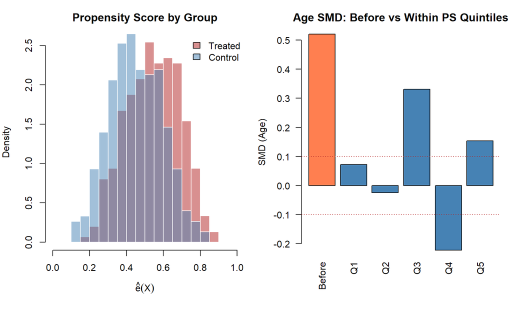

```r
N_ps <- 600
age_ps  <- rnorm(N_ps, 45, 10)
male_ps <- rbinom(N_ps, 1, 0.5)
inc_ps  <- rnorm(N_ps, 50000, 15000)

lp_ps <- -3 + 0.04 * age_ps + 0.5 * male_ps + 0.00002 * inc_ps
Z_ps <- rbinom(N_ps, 1, plogis(lp_ps))

ps_model <- glm(Z_ps ~ age_ps + male_ps + inc_ps, family = binomial)
ps_vals <- fitted(ps_model)

par(mfrow = c(1, 2), mar = c(5.5, 4, 3, 1))

# Panel 1: PS histograms by group
hist(ps_vals[Z_ps == 1], breaks = 25, col = adjustcolor("firebrick", 0.5),
     border = "white", probability = TRUE, xlim = c(0, 1),
     main = "Propensity Score by Group",
     xlab = expression(hat(e)(X)))
hist(ps_vals[Z_ps == 0], breaks = 25, col = adjustcolor("steelblue", 0.5),
     border = "white", probability = TRUE, add = TRUE)
legend("topright", legend = c("Treated", "Control"),
       fill = adjustcolor(c("firebrick", "steelblue"), 0.5), bty = "n")

# Panel 2: balance within PS quintiles
ps_quintile <- cut(ps_vals, breaks = quantile(ps_vals, probs = 0:5 / 5), include.lowest = TRUE)
smd_overall <- (mean(age_ps[Z_ps == 1]) - mean(age_ps[Z_ps == 0])) /
               sqrt((var(age_ps[Z_ps == 1]) + var(age_ps[Z_ps == 0])) / 2)
smd_within <- sapply(levels(ps_quintile), function(q) {
  idx <- ps_quintile == q
  if (sum(Z_ps[idx] == 1) > 1 & sum(Z_ps[idx] == 0) > 1) {
    a_t <- age_ps[idx & Z_ps == 1]; a_c <- age_ps[idx & Z_ps == 0]
    (mean(a_t) - mean(a_c)) / sqrt((var(a_t) + var(a_c)) / 2)
  } else NA
})

barplot(c(smd_overall, smd_within), col = c("coral", rep("steelblue", 5)),
        main = "Age SMD: Before vs Within PS Quintiles",
        ylab = "SMD (Age)", names.arg = c("Before", paste0("Q", 1:5)), las = 2)
abline(h = c(-0.1, 0.1), lty = 3, col = "firebrick")
```

### Estimating the propensity score

In practice, use logistic regression:

$$\Pr(Z = 1 \mid X) = \frac{\exp(\alpha +
\beta^\top X)}{1 + \exp(\alpha + \beta^\top X)}$$

**Important:** The goal is NOT prediction accuracy. The goal is **covariate balance** after matching or weighting.

**How to interpret coefficients:** They tell you what predicts SELECTION into treatment, NOT causal effects. A large positive coefficient on age means older people are more likely to be treated.

**Don’t include instruments** (things that affect $Z$ but not $Y$) – they increase variance without reducing bias.

**Always check:** overlap (PS histograms) and balance (SMDs after matching/weighting).

# 9. Week 7: Estimating Causal Effects – IPW, AIPW, and Diagnostics

## 9.1 Design vs. Analysis: A Two-Phase Approach

**Design phase (NO outcomes):** Estimate PS, match/weight, check balance (SMDs, Love plots, overlap). Iterate until balance is good.

**Analysis phase (NOW use Y):** Estimate $\hat{\tau}$, build CI.

**Why separate?** If you look at outcomes first, you might choose the method that gives the answer you want. This mirrors how clinical trials lock in the analysis plan before unblinding.

**Concrete example of what goes wrong:** Suppose during matching you notice that some treated units have very low outcomes, making them “hard to match.” If you drop them (because their outcomes look weird), you bias the estimated effect upward – you’ve cherry-picked the treated units with good outcomes. This is exactly the kind of fishing that the design/analysis separation prevents.

### Visualizing the Pipeline

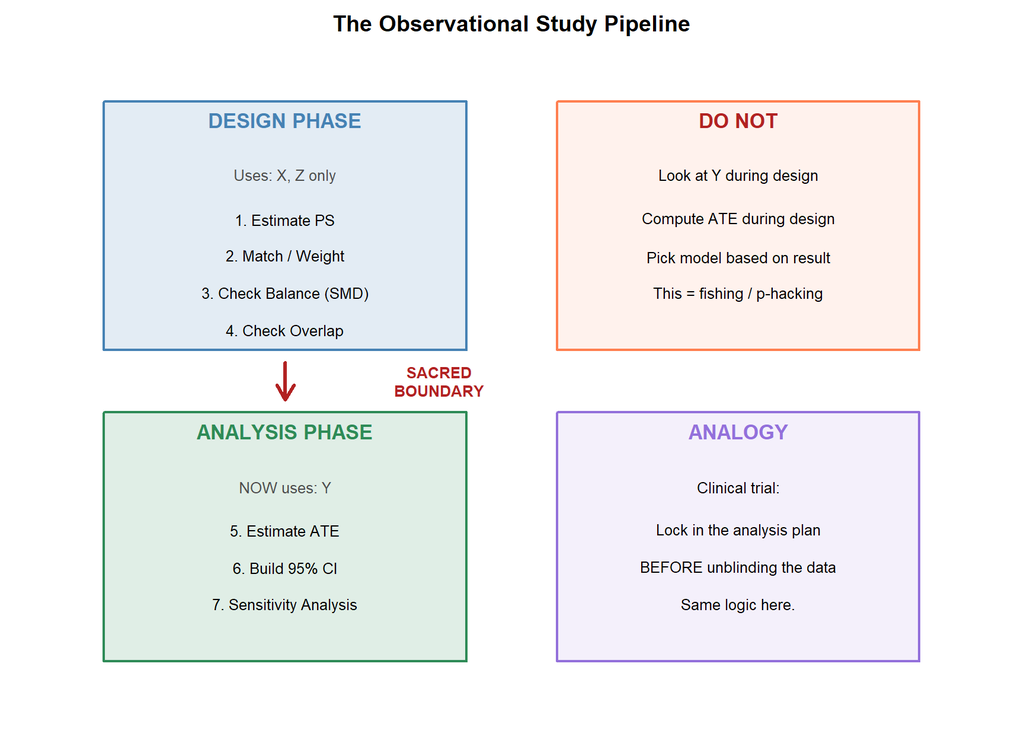

```r
par(mar = c(1, 1, 2, 1))
plot(NA, xlim = c(0, 10), ylim = c(0, 10), xaxt = "n", yaxt = "n",
     xlab = "", ylab = "", main = "The Observational Study Pipeline", bty = "n")

# Design phase
rect(0.5, 5.5, 4.5, 9.5, col = adjustcolor("steelblue", 0.15), border = "steelblue", lwd = 2)
text(2.5, 9.2, "DESIGN PHASE", font = 2, col = "steelblue", cex = 1.1)
text(2.5, 8.3, "Uses: X, Z only", cex = 0.8, col = "gray30")
text(2.5, 7.6, "1. Estimate PS", cex = 0.8)
text(2.5, 7.0, "2. Match / Weight", cex = 0.8)
text(2.5, 6.4, "3. Check Balance (SMD)", cex = 0.8)
text(2.5, 5.8, "4. Check Overlap", cex = 0.8)

# Arrow
arrows(2.5, 5.3, 2.5, 4.7, lwd = 3, col = "firebrick", length = 0.15)
text(4.2, 5.0, "SACRED\nBOUNDARY", col = "firebrick", font = 2, cex = 0.8)

# Analysis phase
rect(0.5, 0.5, 4.5, 4.5, col = adjustcolor("seagreen", 0.15), border = "seagreen", lwd = 2)
text(2.5, 4.2, "ANALYSIS PHASE", font = 2, col = "seagreen", cex = 1.1)
text(2.5, 3.3, "NOW uses: Y", cex = 0.8, col = "gray30")
text(2.5, 2.6, "5. Estimate ATE", cex = 0.8)
text(2.5, 2.0, "6. Build 95% CI", cex = 0.8)
text(2.5, 1.4, "7. Sensitivity Analysis", cex = 0.8)

# DO NOT box
rect(5.5, 5.5, 9.5, 9.5, col = adjustcolor("coral", 0.1), border = "coral", lwd = 2)
text(7.5, 9.2, "DO NOT", font = 2, col = "firebrick", cex = 1.1)
text(7.5, 8.3, "Look at Y during design", cex = 0.8)
text(7.5, 7.6, "Compute ATE during design", cex = 0.8)
text(7.5, 7.0, "Pick model based on result", cex = 0.8)
text(7.5, 6.4, "This = fishing / p-hacking", cex = 0.8)

# Analogy box
rect(5.5, 0.5, 9.5, 4.5, col = adjustcolor("mediumpurple", 0.1), border = "mediumpurple", lwd = 2)
text(7.5, 4.2, "ANALOGY", font = 2, col = "mediumpurple", cex = 1.1)
text(7.5, 3.3, "Clinical trial:", cex = 0.8)
text(7.5, 2.6, "Lock in the analysis plan", cex = 0.8)
text(7.5, 2.0, "BEFORE unblinding the data", cex = 0.8)
text(7.5, 1.4, "Same logic here.", cex = 0.8)
```

## 9.2 Subclassification (Stratification)

Instead of matching individual pairs, you can sort everyone into buckets based on their propensity score (e.g., 5 groups: the bottom 20%, next 20%, etc.). Within each bucket, treated and control people have similar PS values, so they are roughly comparable. Then you compute the treatment effect within each bucket and take a weighted average:

$$\hat{\tau}_{\text{strat}} =
\sum_{k=1}^{K} \frac{N_k}{N} \left(\bar{Y}_{T,k} -
\bar{Y}_{C,k}\right)$$

A classic result (Cochran 1968): just 5 buckets removes about 90% of the bias. More buckets = even less bias, but each bucket has fewer people in it so the estimates within each bucket get noisier.

**Watch out for sparse buckets:** If one bucket has, say, 1 treated person and 42 controls, the treatment effect estimate for that bucket is based on a single person – basically useless. **Fix:** Merge it with a neighboring bucket, or just use fewer buckets overall.

**If your PS model is wrong:** Garbage in, garbage out. Stratifying on a badly estimated PS can actually make things WORSE than not stratifying at all. Always check balance within your strata.

## 9.3 Inverse Probability Weighting (IPW)

IPW **reweights** every person so that the weighted groups look like a randomized experiment.

### The intuition – a concrete example

- College-educated people: 80% enroll in training ($e(X) = 0.8$)
- Non-college people: 20% enroll ($e(X) = 0.2$)

The treated group is 80% college. That does NOT look like the population. IPW fixes this:

- Treated college person: weight $1/0.8 = 1.25$ (over-represented, downweight)
- Treated non-college person: weight $1/0.2 = 5$ (rare, upweight a lot)

After reweighting, both groups look like the overall population.

### The IPW estimator

$$\hat{\tau}_{\text{IPW}} =
\frac{1}{N}\sum_{i=1}^{N}\left[\frac{Z_i Y_i}{\hat{e}(X_i)} -
\frac{(1-Z_i)Y_i}{1-\hat{e}(X_i)}\right]$$

**IPW estimator for the ATT:**

$$\hat{\tau}_{\text{ATT}} =
\frac{1}{n_1}\sum_{i=1}^{N}\left[Z_i Y_i -
\frac{\hat{e}(X_i)(1-Z_i)Y_i}{1-\hat{e}(X_i)}\right]$$

The control group is reweighted so the reweighted controls look like the treated group. This is useful when the estimand of interest is the effect on those who actually received treatment.

### Why IPW is unbiased (key proof)

The idea: when you divide by $e(X)$, the propensity score in the numerator (from $\mathbb{E}[Z \mid X] = e(X)$) cancels with the one in the denominator, leaving you with exactly what you want.

$$\mathbb{E}\left[\frac{Z_i
Y_i}{e(X_i)}\right] = \mathbb{E}\left[\frac{e(X_i) \cdot
\mathbb{E}[Y_i(1) \mid X_i]}{e(X_i)}\right] =
\mathbb{E}[Y_i(1)]$$

Step by step: use the tower property (condition on $X$ first). Given $X$, $Z$ is just a coin flip with probability $e(X)$, and $Y_i(1)$ is fixed. So $\mathbb{E}[Z_i Y_i(1) \mid X_i] = e(X_i) \cdot \mathbb{E}[Y_i(1) \mid X_i]$. Divide by $e(X_i)$ and the PS cancels perfectly.

### IPW achieves covariate balance as a theorem

If the PS is correct, the IPW-weighted treated group has the same average of EVERY covariate as the overall population. Same for the control group. **This is not a hope – it is a guaranteed mathematical fact.**

**Full proof (know this for the exam):** For any function $g(X)$ (could be $X$ itself, $X^2$, $\log X$, whatever):

$$\mathbb{E}\left[\frac{Z \cdot
g(X)}{e(X)}\right] = \mathbb{E}\left[\mathbb{E}\left[\frac{Z \cdot
g(X)}{e(X)} \,\Big|\, X\right]\right] \quad\text{(tower property: break
into subgroup averages)}$$

$$= \mathbb{E}\left[\frac{g(X)}{e(X)}
\cdot \mathbb{E}[Z \mid X]\right] \quad\text{(given X, g(X) and e(X) are
just numbers, pull them out)}$$

$$= \mathbb{E}\left[\frac{g(X)}{e(X)}
\cdot e(X)\right] = \mathbb{E}[g(X)] \quad\text{(e(X)
cancels!)}$$

This works for ANY $g$: $g(X) = X$, $g(X) = X^2$, $g(X) = \sin(X)$, anything. So IPW-weighted treated group has the same mean of every function of covariates as the population. If this doesn’t hold in your data, your PS model is wrong.

### Expected value of IPW weights: E[w_i] = 2 (exam proof)

Each person’s IPW weight has two pieces: one for being treated ($Z/e(X)$) and one for being control ($(1-Z)/(1-e(X))$). Only one piece is ever “on” for a given person (either $Z=1$ or $Z=0$). But on average, each piece contributes 1, so the average weight is 2.

Define the IPW weight for ATE as $w_i = \frac{Z_i}{e(X_i)} + \frac{1-Z_i}{1-e(X_i)}$. Then:

$$\mathbb{E}[w_i] =
\mathbb{E}\left[\mathbb{E}\left[\frac{Z_i}{e(X_i)} +
\frac{1-Z_i}{1-e(X_i)} \;\Big|\; X_i\right]\right] \quad\text{(tower
property)}$$

Given $X_i$: $\mathbb{E}[Z_i/e(X_i) \mid X_i] = e(X_i)/e(X_i) = 1$, and $\mathbb{E}[(1-Z_i)/(1-e(X_i)) \mid X_i] = (1-e(X_i))/(1-e(X_i)) = 1$.

So $\mathbb{E}[w_i] = \mathbb{E}[1 + 1] = 2$.

### Effective Sample Size (ESS) – why weight variability hurts

Think of it this way: if one person has weight 100 and everyone else has weight 2, that one person basically IS your entire estimate. You technically have $N$ people in your sample, but it is as if you only have a few because one person’s outcome is drowning out everyone else’s.

The **effective sample size** tells you how many equally-weighted people your weighted sample is actually worth:

$$\text{ESS} \approx
\frac{\left(\sum_{i=1}^{N} w_i\right)^2}{\sum_{i=1}^{N}
w_i^2}$$

If all weights are equal ($w_i = c$), then $\text{ESS} = (Nc)^2/(Nc^2) = N$ – full sample. If a few weights are very large, $\sum w_i^2$ is dominated by the big ones and ESS shrinks dramatically.

**Concrete example (from exam review):** Suppose $N$ units, half with $e(X) = 0.5$ and half with $e(X) = 0.01$.

- Units with $e(X) = 0.5$: $w_i = Z_i/0.5 + (1-Z_i)/0.5 = 2$ regardless of treatment.
- Units with $e(X) = 0.01$, treated ($Z_i = 1$): $w_i = 1/0.01 = 100$.
- Units with $e(X) = 0.01$, control ($Z_i = 0$): $w_i = 1/0.99 \approx 1.01$.

The treated units with $e(X) = 0.01$ have weight 100 – they each “count” as much as 50 normal-weight units. These few extreme weights dominate $\sum w_i^2$, making ESS far smaller than $N$. The estimator is technically unbiased but practically useless due to enormous variance.

### Visualizing IPW: How Reweighting Creates Balance

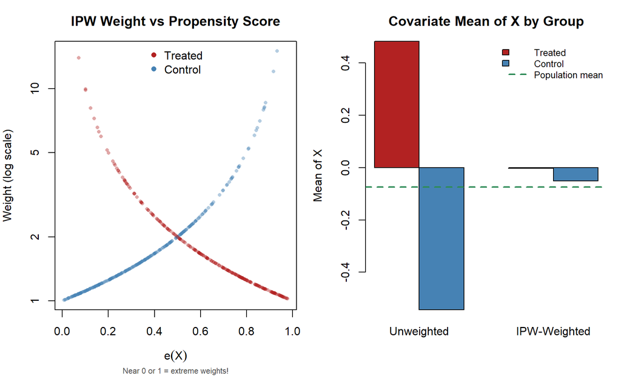

```r
N_ipw <- 500
X_ipw <- rnorm(N_ipw, 0, 1)
ps_true_ipw <- plogis(1.5 * X_ipw)
Z_ipw <- rbinom(N_ipw, 1, ps_true_ipw)
w_ipw <- ifelse(Z_ipw == 1, 1 / ps_true_ipw, 1 / (1 - ps_true_ipw))

par(mfrow = c(1, 2), mar = c(5, 4, 3, 1))

# Panel 1: PS vs weight
plot(ps_true_ipw, w_ipw, pch = 16,
     col = adjustcolor(ifelse(Z_ipw == 1, "firebrick", "steelblue"), 0.4),
     cex = 0.7, log = "y",
     main = "IPW Weight vs Propensity Score",
     xlab = expression(e(X)), ylab = "Weight (log scale)")
legend("top", legend = c("Treated", "Control"),
       col = c("firebrick", "steelblue"), pch = 16, bty = "n")
mtext("Near 0 or 1 = extreme weights!", side = 1, line = 3.8, cex = 0.7, col = "gray30")

# Panel 2: balance before and after weighting
mean_x_t_raw <- mean(X_ipw[Z_ipw == 1])
mean_x_c_raw <- mean(X_ipw[Z_ipw == 0])
mean_x_t_ipw <- sum(Z_ipw * X_ipw / ps_true_ipw) / sum(Z_ipw / ps_true_ipw)
mean_x_c_ipw <- sum((1 - Z_ipw) * X_ipw / (1 - ps_true_ipw)) / sum((1 - Z_ipw) / (1 - ps_true_ipw))

vals_ipw <- matrix(c(mean_x_t_raw, mean_x_c_raw, mean_x_t_ipw, mean_x_c_ipw),
               nrow = 2, dimnames = list(c("Treated", "Control"), c("Unweighted", "IPW-Weighted")))
barplot(vals_ipw, beside = TRUE, col = c("firebrick", "steelblue"),
        main = "Covariate Mean of X by Group", ylab = "Mean of X")
abline(h = mean(X_ipw), lty = 2, col = "seagreen", lwd = 2)
legend("topright", legend = c("Treated", "Control", "Population mean"),
       fill = c("firebrick", "steelblue", NA), lty = c(NA, NA, 2),
       col = c(NA, NA, "seagreen"), lwd = c(NA, NA, 2),
       border = c("black", "black", NA), bty = "n", cex = 0.8)
```

**What you see:** Left: when PS is near 0 or 1, weights explode (note log scale). Right: before weighting, treated has higher X. After IPW, both match the population mean (green dashed).

## 9.4 The Problem with Extreme Weights

If $e(X) \approx 0$ or $1$, weights blow up. One person can dominate the entire estimate.

### Visualizing Extreme Weights and the Overlap Problem

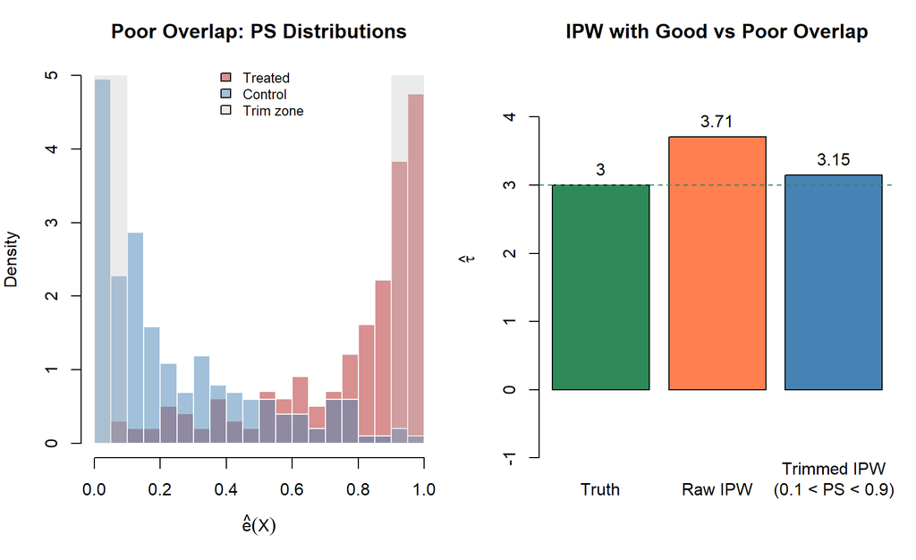

```r
N_ew <- 400
X_ew <- c(rnorm(200, -1, 0.8), rnorm(200, 1, 0.8))
ps_ew <- plogis(2 * X_ew)
Z_ew <- rbinom(N_ew, 1, ps_ew)
Y0_ew <- 2 * X_ew + rnorm(N_ew, 0, 2)
Y1_ew <- Y0_ew + 3
Y_ew <- ifelse(Z_ew == 1, Y1_ew, Y0_ew)

ipw_raw <- mean(Z_ew * Y_ew / ps_ew - (1 - Z_ew) * Y_ew / (1 - ps_ew))

keep_ew <- ps_ew > 0.1 & ps_ew < 0.9
ipw_trimmed <- mean(Z_ew[keep_ew] * Y_ew[keep_ew] / ps_ew[keep_ew] -
                    (1 - Z_ew[keep_ew]) * Y_ew[keep_ew] / (1 - ps_ew[keep_ew]))

par(mfrow = c(1, 2), mar = c(5, 4, 3, 1))

# Panel 1: PS histogram showing poor overlap
hist(ps_ew[Z_ew == 1], breaks = 30, col = adjustcolor("firebrick", 0.5),
     border = "white", probability = TRUE, xlim = c(0, 1),
     main = "Poor Overlap: PS Distributions",
     xlab = expression(hat(e)(X)), ylim = c(0, 5))
hist(ps_ew[Z_ew == 0], breaks = 30, col = adjustcolor("steelblue", 0.5),
     border = "white", probability = TRUE, add = TRUE)
rect(0, 0, 0.1, 5, col = adjustcolor("gray", 0.3), border = NA)
rect(0.9, 0, 1, 5, col = adjustcolor("gray", 0.3), border = NA)
legend("top", legend = c("Treated", "Control", "Trim zone"),
       fill = c(adjustcolor("firebrick", 0.5), adjustcolor("steelblue", 0.5),
                adjustcolor("gray", 0.3)), bty = "n", cex = 0.8)

# Panel 2: estimates
vals_ew <- c(3, ipw_raw, ipw_trimmed)
names(vals_ew) <- c("Truth", "Raw IPW", "Trimmed IPW\n(0.1 < PS < 0.9)")
bp <- barplot(vals_ew, col = c("seagreen", "coral", "steelblue"),
        main = "IPW with Good vs Poor Overlap",
        ylab = expression(hat(tau)), ylim = c(min(0, min(vals_ew)) - 1, max(vals_ew) * 1.3))
text(bp, vals_ew, labels = round(vals_ew, 2), pos = 3)
abline(h = 3, lty = 2, col = "seagreen")
```

**What you see:** With poor overlap, raw IPW (coral) can be wildly off because a few extreme-weight people dominate. Trimming to the overlap region (blue) gives a much more stable estimate. Gray zones = where we trim.

### Solutions to extreme weights

**1. Trimming:** Just throw away people with extreme PS values (e.g., drop anyone with PS below 0.1 or above 0.9). The downside: you are now estimating the treatment effect for a smaller, more “in the middle” group – not the full population. But at least the estimate is stable.

**2. Stabilized weights:** Instead of $1/e(X)$, multiply by the overall fraction treated: $w_i^{stab} = Z_i \cdot \hat{p}/\hat{e}(X_i) + (1-Z_i)(1-\hat{p})/(1-\hat{e}(X_i))$ where $\hat{p} = n_1/N$. This shrinks the extreme weights toward more reasonable values while keeping the balancing property. Think of it as: the raw weights ask “what if everyone were treated?” while stabilized weights ask “what if treatment were distributed proportionally?”

**3. Hajek estimator:** Instead of summing up the weighted outcomes, divide by the sum of the weights:

$$\hat{\tau}_{\text{Hajek}} = \frac{\sum
Z_i Y_i / \hat{e}(X_i)}{\sum Z_i / \hat{e}(X_i)} - \frac{\sum (1-Z_i)Y_i
/ (1-\hat{e}(X_i))}{\sum (1-Z_i) / (1-\hat{e}(X_i))}$$

This forces the weights to add up to 1 in each group. Technically introduces a tiny bias, but WAY lower variance. Almost always better in practice.

## 9.5 Augmented Inverse Probability Weighting (AIPW) – The “Best of Both Worlds”

Here is the problem: regression needs the outcome model to be right, IPW needs the PS model to be right. What if you are not sure which one you got right? AIPW gives you **two chances** – it works if EITHER model is correct.

| Method | What it needs to be right | What goes wrong if it is wrong |
| --- | --- | --- |
| Outcome regression | The outcome model (how $Y$ depends on $X$) | Wrong model = biased estimate |
| IPW | The PS model (how $Z$ depends on $X$) | Wrong PS = bad weights = biased and noisy |
| **AIPW** | **EITHER one** | Only fails if BOTH are wrong |

### The AIPW estimator

$$\hat{\tau}_{\text{AIPW}} =
\frac{1}{N}\sum_{i=1}^{N}\left[\hat{\mu}_1(X_i) - \hat{\mu}_0(X_i) +
\frac{Z_i(Y_i - \hat{\mu}_1(X_i))}{\hat{e}(X_i)} - \frac{(1-Z_i)(Y_i -
\hat{\mu}_0(X_i))}{1-\hat{e}(X_i)}\right]$$

**Read the 4 terms in English:**

- $\hat{\mu}_1(X_i)$: your best prediction of what $Y$ would be if person $i$ were treated (from the outcome model)
- $\hat{\mu}_0(X_i)$: your best prediction if they were NOT treated
- $\hat{\mu}_1 - \hat{\mu}_0$: the regression-based estimate of the treatment effect
- $Z_i(Y_i - \hat{\mu}_1)/\hat{e}$: “how wrong was my prediction for this treated person, weighted by IPW.” This is the correction term – if the outcome model was off, this catches the error.
- $(1-Z_i)(Y_i - \hat{\mu}_0)/(1-\hat{e})$: same correction for control people.

**How it self-corrects:**

- If the regression is perfect: $Y_i - \hat{\mu}_1 = 0$ for treated people, the correction terms vanish, and you just get the regression answer. The PS model does not even matter.
- If the regression is garbage but PS is correct: the correction terms ($Y - \hat{\mu}$ divided by PS) rescue the estimate by reweighting the errors.
- If both are decent: you get something better than either alone.

### The “doubly robust” property

Gives you the right answer if **either** model is correct. You get two shots at being right. Only fails if you screw up both models.

### Visualizing AIPW: Double Robustness

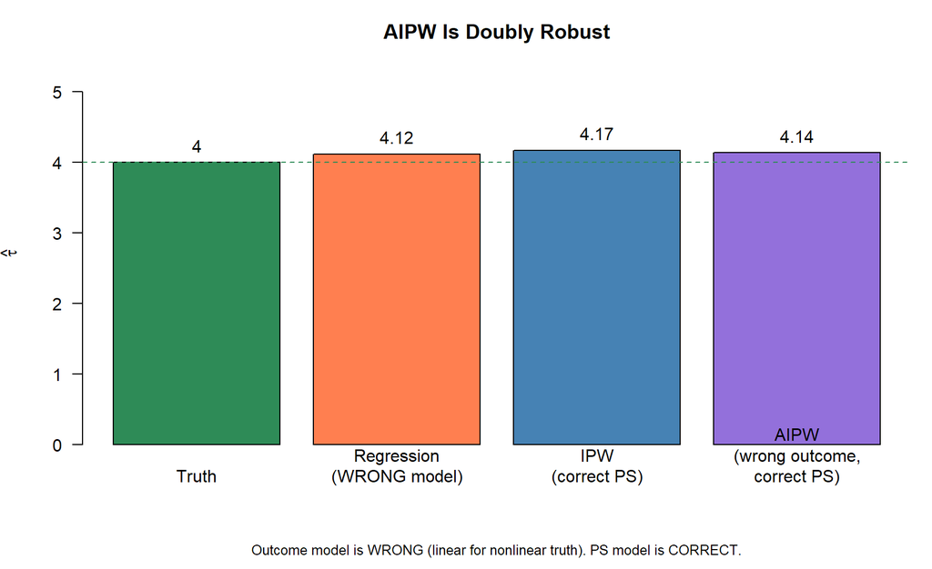

```r
N_aipw <- 800
X_aipw <- rnorm(N_aipw, 0, 1)
ps_aipw <- plogis(0.5 * X_aipw)
Z_aipw <- rbinom(N_aipw, 1, ps_aipw)
Y0_aipw <- 2 + 3 * X_aipw + 0.5 * X_aipw^2 + rnorm(N_aipw, 0, 2)  # nonlinear
Y1_aipw <- Y0_aipw + 4
Y_aipw <- ifelse(Z_aipw == 1, Y1_aipw, Y0_aipw)

# correct PS model
ps_correct <- fitted(glm(Z_aipw ~ X_aipw, family = binomial))

# WRONG outcome model (linear only, but truth is quadratic)
mu1_wrong <- predict(lm(Y_aipw ~ X_aipw, subset = Z_aipw == 1),
                     newdata = data.frame(X_aipw = X_aipw))
mu0_wrong <- predict(lm(Y_aipw ~ X_aipw, subset = Z_aipw == 0),
                     newdata = data.frame(X_aipw = X_aipw))

ipw_est <- mean(Z_aipw * Y_aipw / ps_correct - (1 - Z_aipw) * Y_aipw / (1 - ps_correct))
reg_est <- mean(mu1_wrong - mu0_wrong)
aipw_est <- mean(mu1_wrong - mu0_wrong +
                 Z_aipw * (Y_aipw - mu1_wrong) / ps_correct -
                 (1 - Z_aipw) * (Y_aipw - mu0_wrong) / (1 - ps_correct))

par(mar = c(6, 4, 3, 1))
vals_aipw <- c(4, reg_est, ipw_est, aipw_est)
names(vals_aipw) <- c("Truth", "Regression\n(WRONG model)", "IPW\n(correct PS)", "AIPW\n(wrong outcome,\ncorrect PS)")
bp <- barplot(vals_aipw, col = c("seagreen", "coral", "steelblue", "mediumpurple"),
        main = "AIPW Is Doubly Robust",
        ylab = expression(hat(tau)), ylim = c(0, max(vals_aipw) * 1.3), las = 1)
text(bp, vals_aipw, labels = round(vals_aipw, 2), pos = 3)
abline(h = 4, lty = 2, col = "seagreen")
mtext("Outcome model is WRONG (linear for nonlinear truth). PS model is CORRECT.",
      side = 1, line = 4.5, cex = 0.8)
```

## 9.6 Reading R Code on the Exam

The exam will probably give you R output and ask you to interpret it. Here is a cheat sheet for reading each piece:

**Propensity score model:**

```r
glm(formula = Z ~ age + education + married, family = binomial, data = df)
```

This is logistic regression predicting who gets treated based on their background. The fitted values are the estimated propensity scores.

IMPORTANT: the coefficients tell you what predicts **getting treated** (selection into treatment), NOT what the treatment does to outcomes. A positive coefficient on `age` means older people are more likely to be treated – it says nothing about whether the treatment helps or hurts older people.

**Distance structure for matching (approxmatch):**

```r
components <- list(mahal = c("age","education"), ps = "ps_logit")
wgts <- c(1, 2)
dist_str <- multigrp_dist_struc(df, "Z", components, wgts)
```

This builds a distance that combines two things: Mahalanobis distance on age and education, and propensity score distance. The `wgts <- c(1, 2)` means the PS component gets **twice** the weight of the Mahalanobis component – so the algorithm cares more about matching on PS than on raw covariates.

**Matching:**

```r
res <- kwaymatching(dist_str, "Z", indexgroup = "treated", design = c(1,1), .data = df)
```

`design = c(1,1)` = 1:1 matching (each treated person gets one control match). `design = c(1,2)` = 1:2 matching (each treated person gets two controls). `exactmatchon = "race"` means “only match people of the same race.” `finebalanceVars = "race"` is softer – it just makes sure the overall race distribution is similar in both groups.

**Regression-based ATE in R:**

```r
m1 <- lm(Y ~ age + educ + married, data = df[df$Z==1,])  # fit a model using ONLY treated people
m0 <- lm(Y ~ age + educ + married, data = df[df$Z==0,])  # fit a model using ONLY control people
mu1 <- predict(m1, df)  # use treated model to predict outcome for EVERYONE
mu0 <- predict(m0, df)  # use control model to predict outcome for EVERYONE
ATE_reg <- mean(mu1 - mu0)  # average the predicted difference
```

The idea: build two separate prediction models (one for how outcomes look under treatment, one for control), then use both to predict outcomes for every person, and take the average difference. This is the “regression-based identification” approach: $\hat{\tau} = \frac{1}{N}\sum[\hat{\mu}_1(X_i) - \hat{\mu}_0(X_i)]$.

**IPW in R:**

```r
tau_ipw <- mean(Z*Y/ps - (1-Z)*Y/(1-ps))
```

**AIPW in R:**

```r
tau_aipw <- mean(mu1 - mu0 + Z*(Y-mu1)/ps - (1-Z)*(Y-mu0)/(1-ps))
```

## 9.7 Diagnostics: How Do You Know It’s Working?

Before you ever look at the outcome, check these things:

1. **SMDs** for every covariate – all should be below 0.1. If any are above 0.25, you have a problem.
2. **Variance ratios** – should be close to 1. If the treated group’s age has twice the spread of the control group’s age, that is a red flag.
3. **Love plots** – plot the SMD before and after matching/weighting. You want to see every dot move toward zero.
4. **Overlap** – make PS histograms for treated vs control and see if they overlap. If the two histograms barely touch, you don’t have comparable groups.

If balance is bad, **stop and fix your PS model or matching design.** Do NOT proceed to estimate the treatment effect with poor balance – the estimate will be garbage.

## 9.8 All Methods Need the Same Assumptions

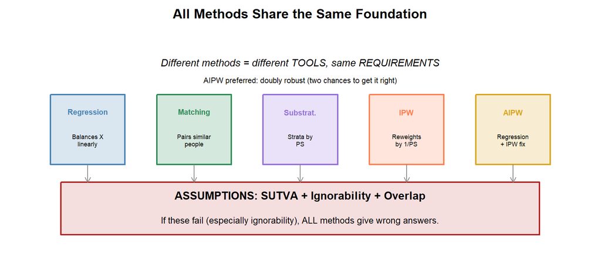

```r
par(mar = c(1, 1, 2, 1))
plot(NA, xlim = c(0, 10), ylim = c(0, 6), xaxt = "n", yaxt = "n",
     xlab = "", ylab = "", bty = "n",
     main = "All Methods Share the Same Foundation")

rect(0.5, 0.3, 9.5, 1.8, col = adjustcolor("firebrick", 0.15), border = "firebrick", lwd = 2)
text(5, 1.4, "ASSUMPTIONS: SUTVA + Ignorability + Overlap", font = 2, cex = 1)
text(5, 0.7, "If these fail (especially ignorability), ALL methods give wrong answers.", cex = 0.8)

methods <- c("Regression", "Matching", "Substrat.", "IPW", "AIPW")
colors <- c("steelblue", "seagreen", "mediumpurple", "coral", "goldenrod")
x_pos <- seq(1, 9, length = 5)
for (i in 1:5) {
  rect(x_pos[i] - 0.7, 2.3, x_pos[i] + 0.7, 4.3,
       col = adjustcolor(colors[i], 0.2), border = colors[i], lwd = 2)
  text(x_pos[i], 3.8, methods[i], font = 2, cex = 0.7, col = colors[i])
}
for (i in 1:5) arrows(x_pos[i], 2.3, x_pos[i], 1.8, length = 0.08, col = "gray50")

texts <- c("Balances X\nlinearly", "Pairs similar\npeople", "Strata by\nPS", "Reweights\nby 1/PS", "Regression\n+ IPW fix")
for (i in 1:5) text(x_pos[i], 3.0, texts[i], cex = 0.55)

text(5, 5.2, "Different methods = different TOOLS, same REQUIREMENTS", cex = 0.9, font = 3)
text(5, 4.7, "AIPW preferred: doubly robust (two chances to get it right)", cex = 0.7)
```

# 10. Key Formulas Cheat Sheet

## Notation Reference

| Symbol | Plain English |
| --- | --- |
| $Y_i(1), Y_i(0)$ | Potential outcomes (what happens with/without treatment) |
| $Z_i$ | Treatment indicator (1 = treated, 0 = control) |
| $X_i$ | Background characteristics (covariates) |
| $Y_i^{\text{obs}}$ | The outcome you actually observe |
| $\tau_i = Y_i(1) - Y_i(0)$ | Individual treatment effect |
| $\tau$ | Average treatment effect across everyone |
| $n_1, n_0, N$ | Number treated, number control, total |
| $e(X)$ | Propensity score = $\Pr(Z=1 \mid X)$ |
| $\bar{Y}_T, \bar{Y}_C$ | Average observed outcome in treated/control group |
| $S_1^2, S_0^2$ | Variance of treated/control potential outcomes |
| $S_\tau^2$ | Variance of individual treatment effects |

## The Formulas

**Observed outcome:**
$$Y_i^{\text{obs}} = Z_i Y_i(1) +
(1-Z_i)Y_i(0)$$

**Average treatment effect (the thing we want):**
$$\tau = \frac{1}{N}\sum_{i=1}^{N}\big[Y_i(1) -
Y_i(0)\big]$$

**Difference-in-means estimator (how we estimate it):**
$$\hat{\tau} = \bar{Y}_T -
\bar{Y}_C$$

**Unbiasedness:** $\mathbb{E}[\hat{\tau}] = \tau$

**Neyman’s exact variance:**
$$\text{Var}(\hat{\tau}) = \frac{S_1^2}{n_1} +
\frac{S_0^2}{n_0} - \frac{S_\tau^2}{N}$$

**Alternate variance form:**
$$\text{Var}(\hat{\tau}) = \frac{n_0}{n_1 N}S_1^2 +
\frac{n_1}{n_0 N}S_0^2 + \frac{2}{N}S_{10}$$

**Conservative variance bound:** $\text{Var}(\hat{\tau}) \le \frac{S_1^2}{n_1} + \frac{S_0^2}{n_0}$

**Neyman’s variance estimator:**
$$\widehat{\text{Var}}(\hat{\tau}) =
\frac{s_1^2}{n_1} + \frac{s_0^2}{n_0}$$

**KEY identity:** $S_\tau^2 = S_1^2 + S_0^2 - 2S_{10}$ ($S_{10}$ is unidentifiable)

**95% CI:** $\hat{\tau} \pm 1.96\sqrt{\widehat{\text{Var}}(\hat{\tau})}$

**FWL residuals:** $\tilde{Z}_i = Z_i - \hat{\mathbb{E}}[Z \mid X_i]$

**Regression coefficient via FWL:**
$$\hat{\tau} = \frac{\sum \tilde{Z}_i Y_i}{\sum
\tilde{Z}_i^2}$$

**Regression balances covariates:** $\sum w_i X_i = 0$

**Misspecification bias:** $\text{Bias}(\hat{\tau}) = \sum w_i \, g(X_i)$

**Fisher’s p-value:** $p = \Pr\big(|T(\mathbf{Z})| \ge |T_{\text{obs}}| \mid H_0\big)$

**Confidence set by inversion:** $\mathcal{C}_{1-\alpha} = \{\tau_0 : p(\tau_0) > \alpha\}$

**SMD:** $\text{SMD}(X) = \frac{\bar{X}_T - \bar{X}_C}{\sqrt{(s_T^2 + s_C^2)/2}}$

**Matching bias bound:** $|\text{Bias}(\hat{\tau}^M)| \le L(|\Delta_X^M| + 2s_D)$

**Selection bias decomposition:**
$$\mathbb{E}[Y|Z\!=\!1] - \mathbb{E}[Y|Z\!=\!0] =
\text{ATT} + \big(\mathbb{E}[Y(0)|Z\!=\!1] -
\mathbb{E}[Y(0)|Z\!=\!0]\big)$$

**Identification under ignorability:**
$$\tau = \mathbb{E}\big[\mathbb{E}[Y \mid Z\!=\!1,
X] - \mathbb{E}[Y \mid Z\!=\!0, X]\big]$$

**Ignorability:** $(Y(1), Y(0)) \perp\!\!\!\perp Z \mid X$

**Overlap:** $0 < \Pr(Z=1 \mid X=x) < 1$ for all $x$

**Propensity score:** $e(X) = \Pr(Z=1 \mid X)$

**Balancing property:** $(Y(1), Y(0)) \perp\!\!\!\perp Z \mid e(X)$

**IPW estimator:**
$$\hat{\tau}_{\text{IPW}} =
\frac{1}{N}\sum_{i=1}^{N}\left[\frac{Z_i Y_i}{\hat{e}(X_i)} -
\frac{(1-Z_i)Y_i}{1-\hat{e}(X_i)}\right]$$

**IPW unbiasedness key step:** $\mathbb{E}\left[\frac{Z_i Y_i}{e(X_i)}\right] = \mathbb{E}[Y_i(1)]$

**IPW weight expectation:** $\mathbb{E}[w_i] = 2$ where $w_i = Z_i/e(X_i) + (1-Z_i)/(1-e(X_i))$

**Effective sample size:** $\text{ESS} \approx \left(\sum w_i\right)^2 / \sum w_i^2$

**Composite distance with categorical penalty:** $d = (X_i - X_j)^2 + \lambda \cdot \mathbf{1}\{W_i \ne W_j\}$

**Hajek (stabilized) estimator:**
$$\hat{\tau}_{\text{Hajek}} = \frac{\sum \frac{Z_i
Y_i}{\hat{e}(X_i)}}{\sum \frac{Z_i}{\hat{e}(X_i)}} - \frac{\sum
\frac{(1-Z_i)Y_i}{1-\hat{e}(X_i)}}{\sum
\frac{(1-Z_i)}{1-\hat{e}(X_i)}}$$

**AIPW (doubly robust) estimator:**
$$\hat{\tau}_{\text{AIPW}} =
\frac{1}{N}\sum\left[\hat{\mu}_1(X_i) - \hat{\mu}_0(X_i) + \frac{Z_i(Y_i
- \hat{\mu}_1(X_i))}{\hat{e}(X_i)} - \frac{(1-Z_i)(Y_i -
\hat{\mu}_0(X_i))}{1-\hat{e}(X_i)}\right]$$

**AIPW doubly robust:** Consistent if $\hat{\mu}_1, \hat{\mu}_0$ correct **OR** $\hat{e}$ correct

**Stabilized weights:** $\tilde{w}_i^{(1)} = \frac{Z_i \cdot \Pr(Z\!=\!1)}{\hat{e}(X_i)}, \quad \tilde{w}_i^{(0)} = \frac{(1-Z_i)\Pr(Z\!=\!0)}{1-\hat{e}(X_i)}$

**ATT:** $\mathbb{E}[Y(1) - Y(0) \mid Z = 1]$ | **ATC:** $\mathbb{E}[Y(1) - Y(0) \mid Z = 0]$

**Matched-pair estimator:** $\hat{\tau}_{\text{match}} = \frac{1}{n_M}\sum_{i:Z_i=1}[Y_i - Y_{j(i)}]$

**Blocked estimator:** $\hat{\tau}_{BL} = \sum_{k=1}^{K}\frac{n_k}{N}(\bar{Y}_{T,k} - \bar{Y}_{C,k})$

**Subclassification:**
$$\hat{\tau}_{\text{strat}} =
\sum_{k=1}^{K}\frac{N_k}{N}\left(\bar{Y}_{T,k} -
\bar{Y}_{C,k}\right)$$

# 11. Practice Questions with Answers

## Q1: What is the fundamental problem of causal inference?

**Answer:** The causal effect for a person is $\tau_i = Y_i(1) - Y_i(0)$: the difference between what happens with treatment and what happens without. The problem is that each person is either treated or not – you see one potential outcome and the other is forever missing. You never observe both $Y_i(1)$ and $Y_i(0)$ for the same person, so individual causal effects are fundamentally unobservable. This is why we focus on estimating **average** effects.

## Q2: How does regression “adjust” for covariates? What does it balance, and what does it miss?

**Answer:** By the FWL theorem, the regression coefficient on treatment is computed by first removing the linear effect of covariates from treatment, then correlating the residuals. This is equivalent to reweighting so that $\sum w_i X_i = 0$.

Regression balances the covariates **included in the model** (linearly). It does NOT balance nonlinear functions ($X^2$), interactions, or unobserved variables. The bias equals $\sum w_i g(X_i)$ where $g(X)$ is the omitted part.

## Q3: Why are randomized experiments the gold standard?

**Answer:** Randomization makes treatment assignment independent of all pre-treatment characteristics. This means treated and control groups are balanced on everything (observed, unobserved, linear, nonlinear). No modeling assumptions needed.

## Q4: Neyman’s variance formula

**Answer:** $\text{Var}(\hat{\tau}) = S_1^2/n_1 + S_0^2/n_0 - S_\tau^2/N$. We use $\widehat{\text{Var}} = s_1^2/n_1 + s_0^2/n_0$ (conservative, drops $-S_\tau^2/N$). Since $S_\tau^2 \ge 0$, this overestimates. Exact when effects are constant ($S_\tau^2 = 0$).

## Q5: Explain Fisher’s randomization test step by step

**Answer:** 1. State null: $H_0: Y_i(1) = Y_i(0)$ for all $i$ 2. Under $H_0$, all potential outcomes known ($= Y_i^{\text{obs}}$) 3. Choose test statistic (e.g., difference in means) 4. Compute observed $T_{\text{obs}}$ 5. Enumerate all $\binom{N}{n_1}$ assignments 6. For each, compute $T$ (outcomes don’t change under $H_0$) 7. p-value = proportion with $|T| \ge |T_{\text{obs}}|$

Exact, no distributional assumptions, valid from randomization alone.

## Q6: What is SUTVA?

**Answer:** (1) No interference – person $i$’s outcome depends only on their own treatment. (2) No hidden versions of treatment. Without SUTVA, $Y_i(1)$ and $Y_i(0)$ are ambiguous.

## Q7: What is ignorability and why can’t you test it?

**Answer:** $(Y(1), Y(0)) \perp\!\!\!\perp Z \mid X$. Conditional on $X$, treatment is as-if-random. Untestable because it is a claim about unobserved potential outcomes. Must be justified by subject-matter knowledge.

## Q8: What is the propensity score and its balancing property?

**Answer:** $e(X) = \Pr(Z=1 \mid X)$. Balancing property: $(Y(1), Y(0)) \perp\!\!\!\perp Z \mid e(X)$. Match on one number instead of all covariates. Coarsest balancing score.

## Q9: What is selection bias? When does it vanish?

**Answer:** $\mathbb{E}[Y|Z\!=\!1] - \mathbb{E}[Y|Z\!=\!0] = \text{ATT} + \text{selection bias}$, where selection bias = $\mathbb{E}[Y(0)|Z\!=\!1] - \mathbb{E}[Y(0)|Z\!=\!0]$. Vanishes under randomization or conditional ignorability.

## Q10: Computation problem

An A/B test assigns 5 of 10 users to a new interface. Observed sessions:

- Treatment: 8, 6, 7, 9, 5
- Control: 4, 6, 5, 3, 4

**(a)** $\hat{\tau} = 7 - 4.4 = 2.6$

**(b)** Under $H_0$, outcomes are fixed at {8,6,7,9,5,4,6,5,3,4}. There are $\binom{10}{5} = 252$ splits. For each, compute $T = \bar{Y}_T - \bar{Y}_C$.

**(c)** $s_1^2 = 2.5$, $s_0^2 = 1.3$, $\widehat{\text{Var}} = 0.76$, SE $= 0.872$, 95% CI: $[0.89, 4.31]$

## Q11: Walk through the identification proof

**Answer:** Start with $\mathbb{E}[Y(1)]$: 1. $= \mathbb{E}[\mathbb{E}[Y(1)|X]]$ (tower property) 2. $= \mathbb{E}[\mathbb{E}[Y(1)|Z\!=\!1,X]]$ (ignorability) 3. $= \mathbb{E}[\mathbb{E}[Y|Z\!=\!1,X]]$ (consistency + overlap)

Same for $Y(0)$. Subtract: $\tau = \mathbb{E}[\mathbb{E}[Y|Z\!=\!1,X] - \mathbb{E}[Y|Z\!=\!0,X]]$.

## Q12: What is IPW and why does it work?

**Answer:** $\hat{\tau}_{\text{IPW}} = \frac{1}{N}\sum\left[\frac{Z_i Y_i}{\hat{e}(X_i)} - \frac{(1-Z_i)Y_i}{1-\hat{e}(X_i)}\right]$. Works because $\mathbb{E}[Z_i Y_i / e(X_i)] = \mathbb{E}[Y_i(1)]$ by tower property + ignorability. The PS cancels.

## Q13: What goes wrong with extreme weights?

**Answer:** When $e(X) \approx 0$ or $1$, weights $1/e(X)$ blow up. One person dominates. Fixes: trimming, Hajek/stabilized weights, AIPW.

## Q14: What is AIPW and what makes it “doubly robust”?

**Answer:** Combines regression + IPW correction. Consistent if EITHER the outcome model or the PS model is correct. If the regression is perfect, the IPW correction vanishes (residuals = 0). If the PS is perfect, the correction fixes bad regression.

## Q15: Why separate design from analysis?

**Answer:** Design phase constructs comparable groups using only $X$ and $Z$ (no outcomes). Prevents specification searching. The boundary is sacred – like pre-registering a clinical trial.

## Q16: Compare matching, IPW, subclassification, and AIPW

| Method | How it works | Strength | Weakness |
| --- | --- | --- | --- |
| Matching | Pairs similar people | Transparent, easy balance check | Discards unmatched data |
| Subclassification | Stratify by PS | Simple, ~90% bias removal | Within-stratum heterogeneity |
| IPW | Reweight by 1/PS | Uses all data, exact balance in theory | Extreme weights |
| AIPW | Regression + IPW fix | Doubly robust, most efficient | Fails if both models wrong |

All require SUTVA + ignorability + overlap.

## Q17: Why is $S_{10}$ unidentifiable?

**Answer:** $S_{10}$ requires both $Y_i(1)$ and $Y_i(0)$ for the same person. We only ever see one. Since $S_\tau^2 = S_1^2 + S_0^2 - 2S_{10}$, $S_\tau^2$ is also unidentifiable. Under constant effects, $S_{10} = S_1^2$ and $S_\tau^2 = 0$.

## Q18: FWL and extrapolation

**Answer:** FWL weights $w_i = \tilde{Z}_i / \sum \tilde{Z}_j^2$ are large at extremes when treated and control occupy different $X$ regions. The regression extrapolates across the gap. Always check covariate overlap.

## Q19: Wilcoxon vs difference-in-means in randomization framework

**Answer:** Both are valid test statistics in Fisher’s test. Difference-in-means: powerful for constant additive effects, sensitive to outliers. Wilcoxon: uses ranks, robust to outliers/skewness. Both have exact p-values.

## Q20: Full observational study pipeline

1. Define question (treatment, outcome, population)
2. List confounders (subject-matter knowledge)
3. Estimate PS (logistic regression)
4. Check overlap (PS histograms)
5. Match or weight
6. Check balance (SMDs < 0.1, Love plot)
7. **NOW look at outcomes** – estimate $\hat{\tau}$, build CI
8. Sensitivity analysis

Steps 3-6 = design phase (NO outcomes). Step 7 = analysis phase.

## Q21: Compute an SMD from raw numbers

$N = 200$, $n_1 = 100$. For covariate age: $\bar{X}_T = 41.2$, $\bar{X}_C = 40.9$, pooled $s_X = 12$.

**Answer:** $\text{SMD} = (41.2 - 40.9) / 12 = 0.025$. This is well below 0.1 – excellent balance. In a randomized experiment, small SMDs like this are expected and do not indicate confounding.

## Q22: Read a balance table and identify problems

After matching, the SMDs are: age (0.05), education (0.08), married (0.12), race_black (0.28).

**Answer:** Age and education are well-balanced (< 0.1). Married is borderline (0.12 > 0.1). Race_black is badly balanced (0.28 >> 0.1). The matching needs improvement – try adding race to the exact matching variables, or use `finebalanceVars = "race"` to enforce marginal balance on race.

## Q23: When does matching outperform IPW?

**Answer:** Matching is stable when most treated and control units have propensity scores near 0.5 – easy to find close matches. IPW becomes unstable when even a few units have extreme PS (near 0 or 1), because those units get huge weights. If the PS distribution is spread out with tails near 0 and 1, matching will typically give more stable estimates than raw IPW.

## Q24: Interpreting R code – logistic regression coefficients

`glm(Z ~ age + married, family=binomial)` gives coefficient 0.8 on `married`.

**Answer:** This means married people are more likely to be SELECTED into treatment (higher log-odds of treatment). This is NOT a causal effect of marriage on anything. It describes the selection process. We use these fitted values as propensity scores for matching or weighting.

## Q25: Interpreting R code – distance weights in matching

`wgts <- c(1, 2)` with `components = list(mahal = c("age"), ps = "ps_logit")`.

**Answer:** The PS component gets twice the weight of Mahalanobis. Matches will prioritize being close in propensity score over being close in raw age. Higher PS weight = better PS balance but potentially worse individual covariate balance. You can check with SMDs after matching.

## Q26: Walk through each term of AIPW in R code

`mean(mu1 - mu0 + Z*(Y-mu1)/ps - (1-Z)*(Y-mu0)/(1-ps))`

**Answer:** Term 1 (`mu1`): predicted outcome under treatment from the outcome model. Term 2 (`mu0`): predicted outcome under control. Their difference = regression estimate of ATE. Term 3 (`Z*(Y-mu1)/ps`): for treated units, this is the regression residual weighted by 1/PS – corrects the regression if the outcome model is wrong. Term 4 (`(1-Z)*(Y-mu0)/(1-ps)`): same correction for control units. If the outcome model is perfect, residuals are 0 and correction vanishes. If the PS model is perfect, the correction rescues a bad outcome model.

## Q27: When all methods fail – unobserved confounding

Treatment = new surgical technique. Outcome = recovery time. Unobserved confounder = disease severity (sicker patients get the old technique because surgeons play it safe).

**Answer:** All methods (regression, matching, IPW, AIPW) assume ignorability – that all confounders are measured. If severity is unmeasured, treated patients are systematically less sick than controls. Every method will estimate a treatment effect that is too large, because it is confounded with the selection of healthier patients into the new technique. No amount of modeling fixes an unmeasured confounder.

## Q29: Prove that E[w_i] = 2 for IPW weights

Define $w_i = Z_i/e(X_i) + (1-Z_i)/(1-e(X_i))$.

**Answer:** Use the tower property: $\mathbb{E}[w_i] = \mathbb{E}[\mathbb{E}[w_i \mid X_i]]$. Given $X_i$: $\mathbb{E}[Z_i/e(X_i) \mid X_i] = \mathbb{E}[Z_i \mid X_i]/e(X_i) = e(X_i)/e(X_i) = 1$. Similarly $\mathbb{E}[(1-Z_i)/(1-e(X_i)) \mid X_i] = (1-e(X_i))/(1-e(X_i)) = 1$. So $\mathbb{E}[w_i \mid X_i] = 2$ for any $X_i$, hence $\mathbb{E}[w_i] = 2$.

## Q30: ESS collapse with extreme propensity scores

Half of $N = 200$ units have $e(X) = 0.5$; the other half have $e(X) = 0.01$. Approximately 1 of those 100 low-PS units is treated. Compute the weights and explain qualitatively what happens to ESS.

**Answer:** For the 100 units with $e(X) = 0.5$: $w_i = 2$ regardless of treatment. For units with $e(X) = 0.01$: if treated, $w_i = 1/0.01 = 100$; if control, $w_i \approx 1.01$. So $\sum w_i \approx 100 \times 2 + 1 \times 100 + 99 \times 1.01 \approx 400$. But $\sum w_i^2 \approx 100 \times 4 + 1 \times 10000 + 99 \times 1.02 \approx 10500$. ESS $\approx 400^2/10500 \approx 15$, versus actual $N = 200$. One unit with weight 100 dominates. The estimator is technically unbiased but has enormous variance.

## Q31: Construct a population where sharp null is false but weak null is true

**Answer:** Four units with potential outcomes:

| $i$ | $Y_i(0)$ | $Y_i(1)$ | $\tau_i$ |
| --- | --- | --- | --- |
| 1 | 0 | 1 | +1 |
| 2 | 0 | 1 | +1 |
| 3 | 1 | 0 | -1 |
| 4 | 1 | 0 | -1 |

$\tau = (1 + 1 - 1 - 1)/4 = 0$, so the weak null is true. But $Y_i(1) \ne Y_i(0)$ for every $i$, so the sharp null is false. The individual effects cancel out on average but are nonzero individually.

## Q32: Deterministic assignment – when does DM fail?

Suppose $Y_i(0) = \alpha + \beta X_i + \varepsilon_i$ and $Y_i(1) = Y_i(0) + \tau$. Treatment is assigned by $Z_i = \mathbf{1}\{X_i > c\}$. Is $\hat{\tau}_{DM}$ unbiased for $\tau$?

**Answer:** No. Under this rule, all treated units have high $X$ and all controls have low $X$. Since $Y_i(0)$ depends linearly on $X$, the treated group has systematically higher $Y(0)$ values. The DM estimator captures $\tau$ plus the mean difference in $\beta X$ between the groups, which is a positive bias term $\beta(\mathbb{E}[X \mid X > c] - \mathbb{E}[X \mid X \le c])$. Without randomization, the DM estimator confounds the treatment effect with the covariate imbalance.

## Q33: Interpreting PS model coefficients and post-matching SMD (exam-style R output)

You fit `glm(Z ~ age + educ + married + black, family=binomial)` and get:

| Coefficient | Estimate |
| --- | --- |
| (Intercept) | -3.00 |
| age | 0.02 |
| educ | 0.10 |
| married | 0.70 |
| black | 0.90 |

After 1:1 PS matching, SMDs: age=0.06, educ=0.05, married=0.09, black=0.18.

1. What does the positive coefficient on `black` mean?
2. Which covariates remain problematic after matching?
3. How would you modify the matching to fix this?

**Answer:** (a) Holding other covariates constant, being black is associated with higher log-odds of receiving treatment. This describes the **selection mechanism**, NOT a causal effect on $Y$. (b) `black` has SMD = 0.18, which exceeds the 0.10 threshold – substantial residual imbalance. All other covariates are well-balanced (< 0.10). This is concerning because race is likely related to both treatment and outcome. (c) Impose exact matching (or near-fine balance) on race while still using PS for other covariates. Alternatively, add a large categorical penalty for mismatching on race in the distance structure: $d = d_{\text{PS}} + \lambda \cdot \mathbf{1}\{\text{race}_i \ne \text{race}_j\}$.